# PAC4 - Tipologia i cicle de vida de les dades

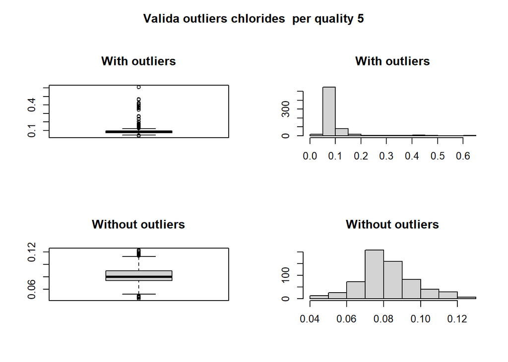

```
## Outliers identificats per la qualitat del vi: 5 :  45
## Proporció (%) de outliers: 7.1
## Mitja dels outliers: 0.24
## Mitja sense eliminar els outliers: 0.09
## Mitja eliminant outliers: 0.08
```

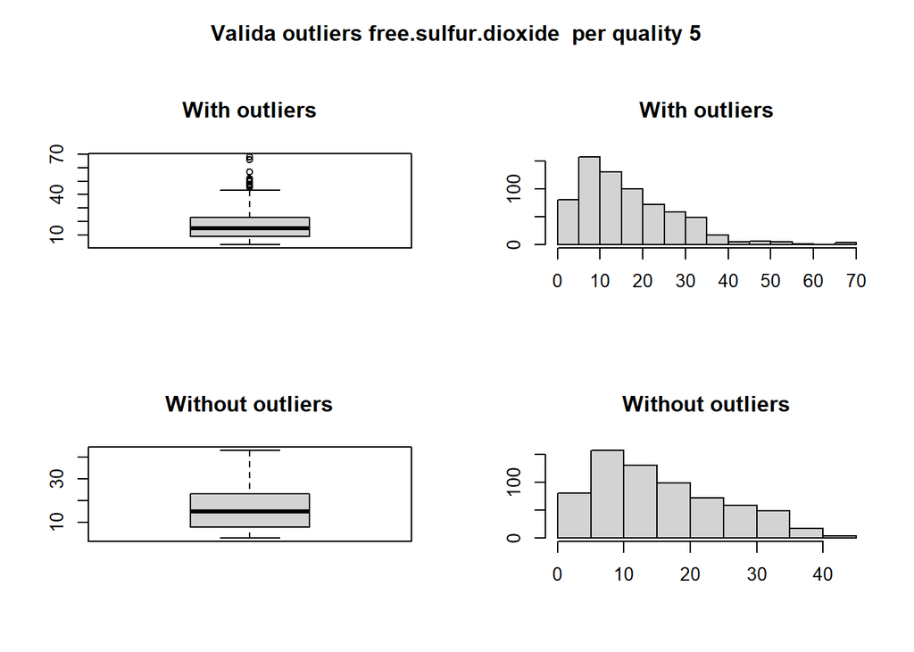

```
## Outliers identificats per la qualitat del vi: 5 :  16
## Proporció (%) de outliers: 2.4
## Mitja dels outliers: 53
## Mitja sense eliminar els outliers: 16.98
## Mitja eliminant outliers: 16.12
```

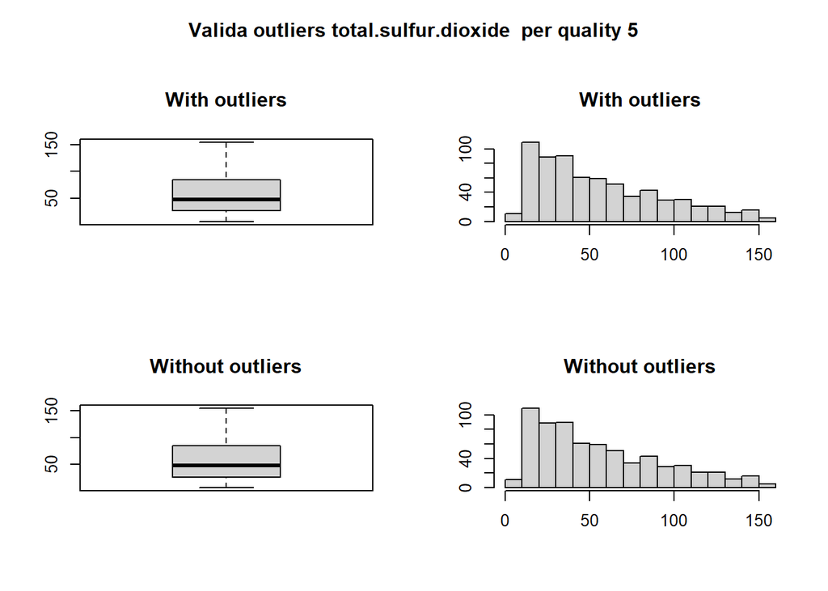

```
## Outliers identificats per la qualitat del vi: 5 :  0
## Proporció (%) de outliers: 0
## Mitja dels outliers: NaN
## Mitja sense eliminar els outliers: 56.51
## Mitja eliminant outliers: 56.51
```

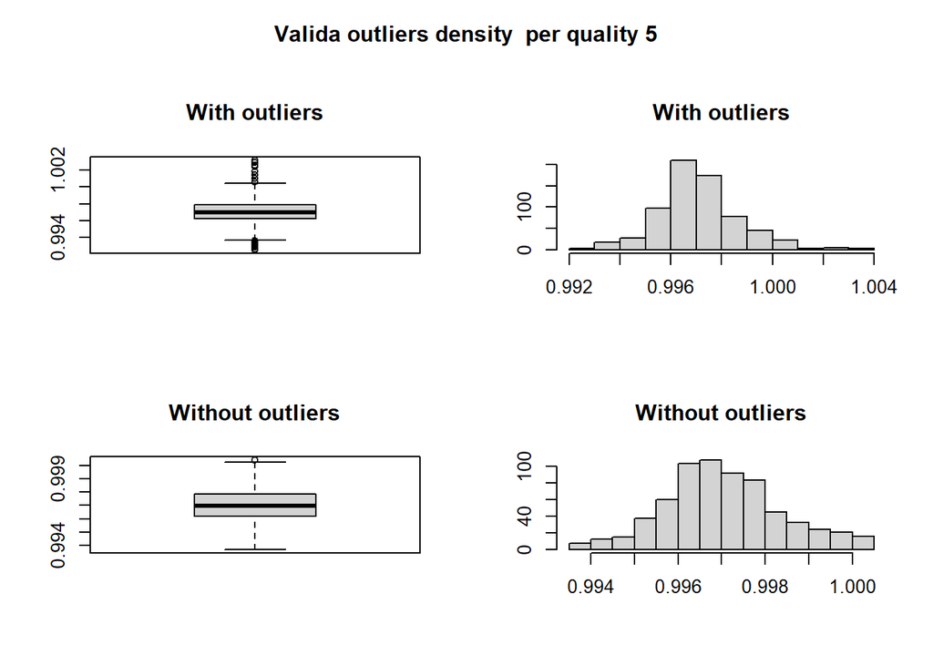

```
## Outliers identificats per la qualitat del vi: 5 :  28
## Proporció (%) de outliers: 4.3
## Mitja dels outliers: 1
## Mitja sense eliminar els outliers: 1
## Mitja eliminant outliers: 1
```

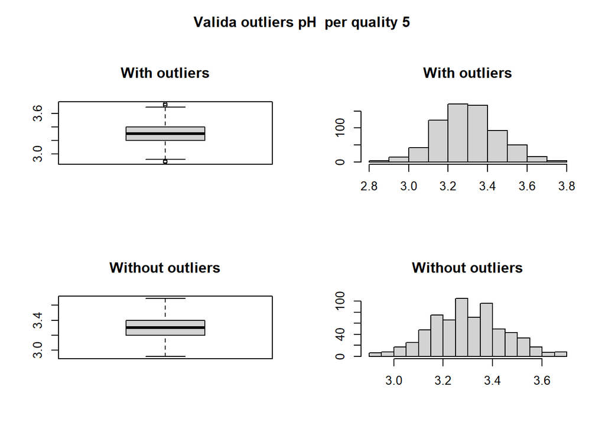

```
## Outliers identificats per la qualitat del vi: 5 :  6
## Proporció (%) de outliers: 0.9
## Mitja dels outliers: 3.31
## Mitja sense eliminar els outliers: 3.3
## Mitja eliminant outliers: 3.3
```

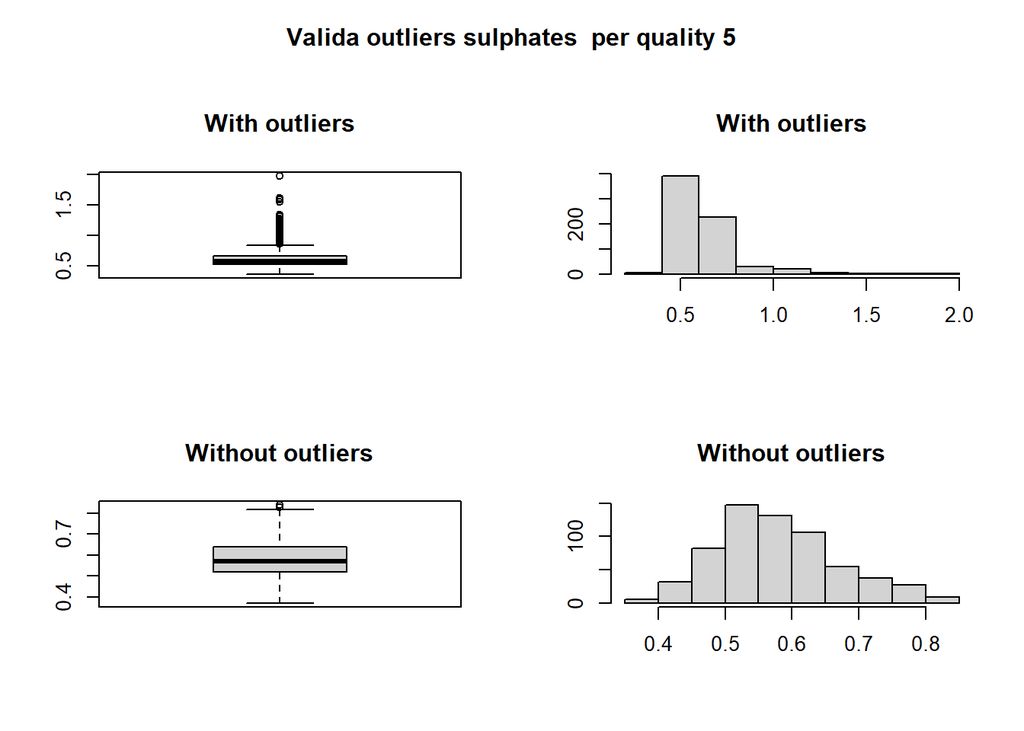

```
## Outliers identificats per la qualitat del vi: 5 :  48
## Proporció (%) de outliers: 7.6
## Mitja dels outliers: 1.11
## Mitja sense eliminar els outliers: 0.62
## Mitja eliminant outliers: 0.58
```

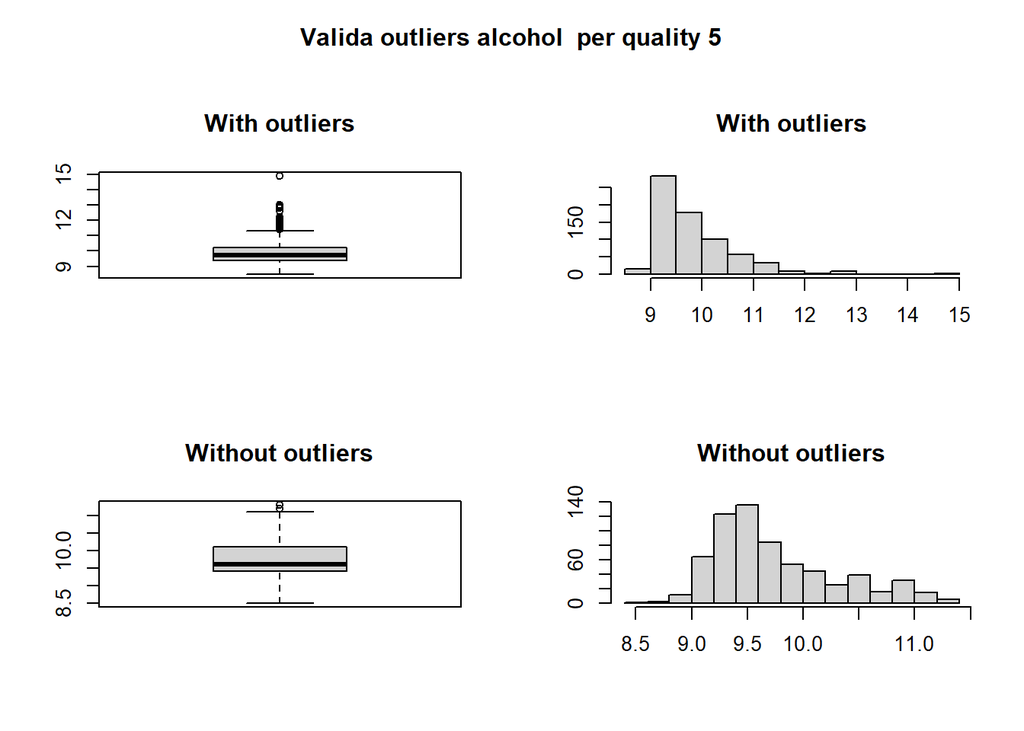

```
## Outliers identificats per la qualitat del vi: 5 :  30
## Proporció (%) de outliers: 4.6
## Mitja dels outliers: 12.07
## Mitja sense eliminar els outliers: 9.9
## Mitja eliminant outliers: 9.8
```

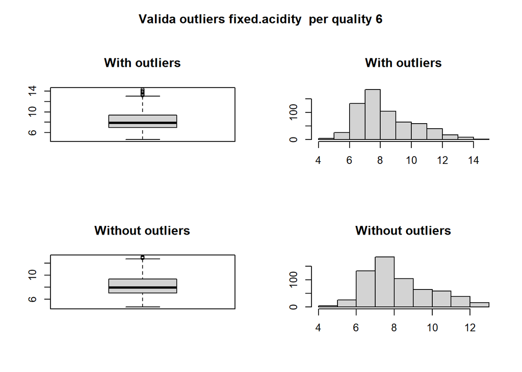

```
## Outliers identificats per la qualitat del vi: 6 :  9
## Proporció (%) de outliers: 1.4
## Mitja dels outliers: 13.62
## Mitja sense eliminar els outliers: 8.35
## Mitja eliminant outliers: 8.27
```

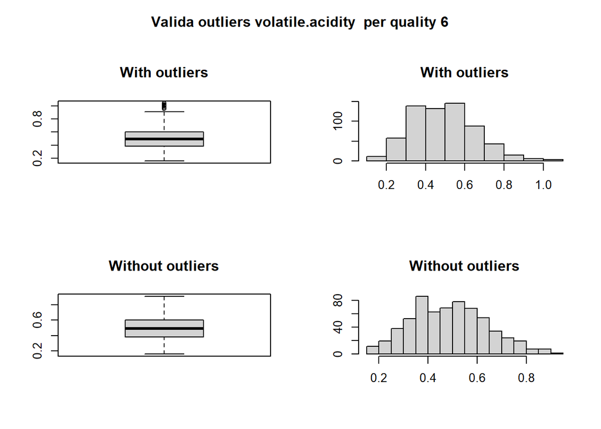

```
## Outliers identificats per la qualitat del vi: 6 :  7
## Proporció (%) de outliers: 1.1
## Mitja dels outliers: 1
## Mitja sense eliminar els outliers: 0.5
## Mitja eliminant outliers: 0.49
```

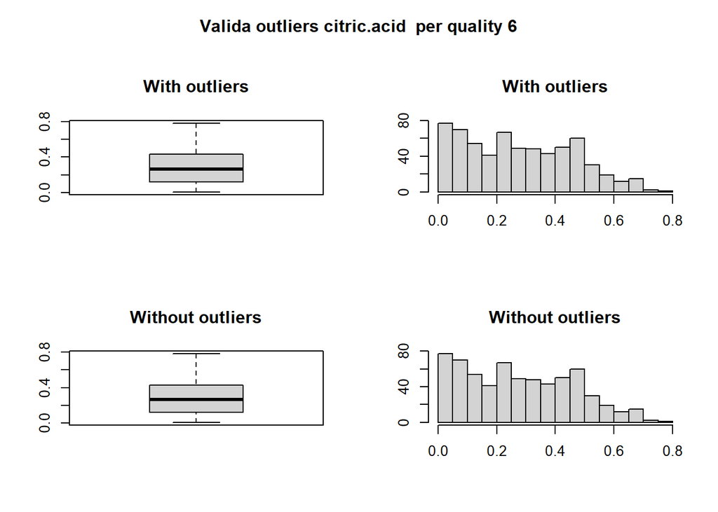

```
## Outliers identificats per la qualitat del vi: 6 :  0
## Proporció (%) de outliers: 0
## Mitja dels outliers: NaN
## Mitja sense eliminar els outliers: 0.28
## Mitja eliminant outliers: 0.28
```

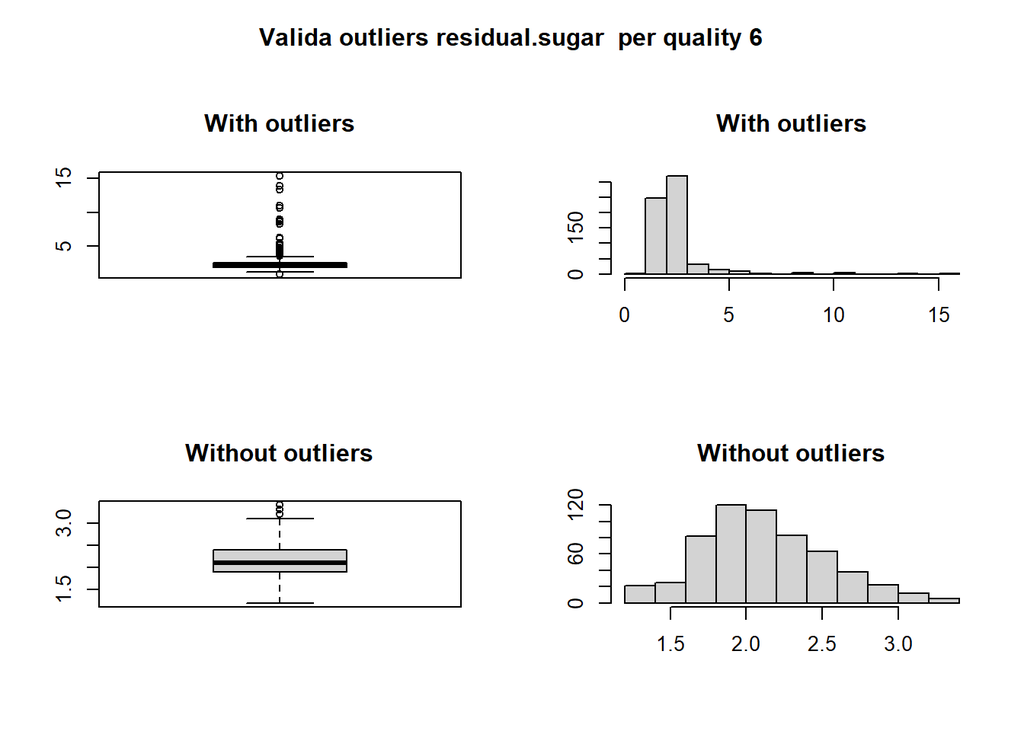

```
## Outliers identificats per la qualitat del vi: 6 :  53
## Proporció (%) de outliers: 9.1
## Mitja dels outliers: 5.85
## Mitja sense eliminar els outliers: 2.48
## Mitja eliminant outliers: 2.17
```

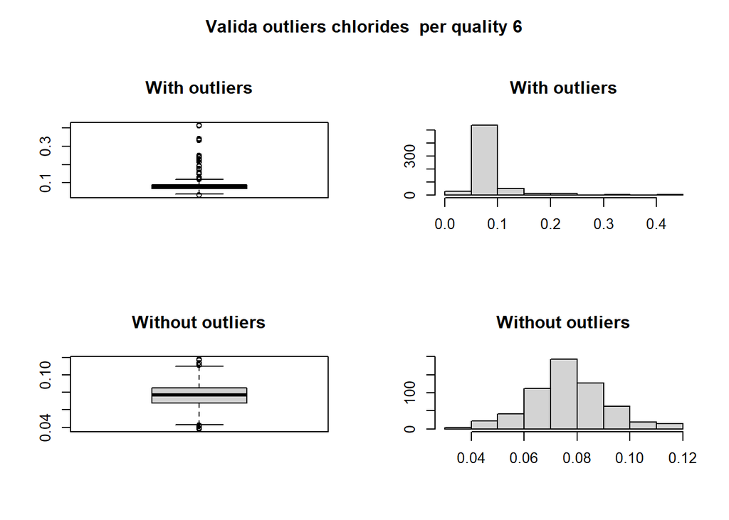

```
## Outliers identificats per la qualitat del vi: 6 :  43
## Proporció (%) de outliers: 7.2
## Mitja dels outliers: 0.19
## Mitja sense eliminar els outliers: 0.08
## Mitja eliminant outliers: 0.08
```

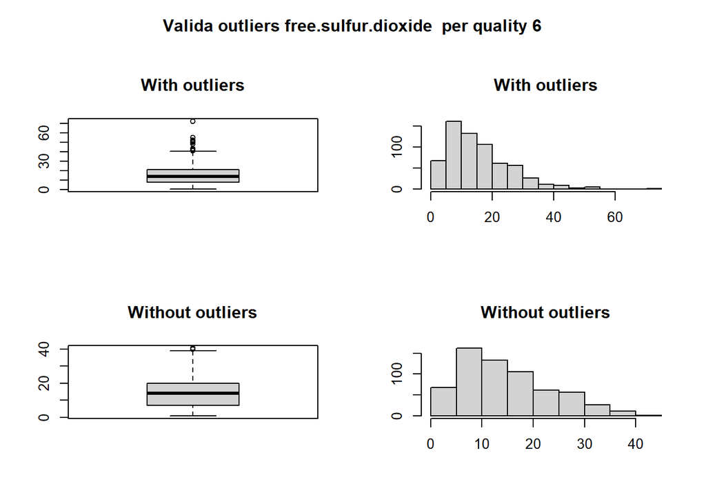

```
## Outliers identificats per la qualitat del vi: 6 :  14
## Proporció (%) de outliers: 2.2
## Mitja dels outliers: 48.07
## Mitja sense eliminar els outliers: 15.71
## Mitja eliminant outliers: 14.99
```

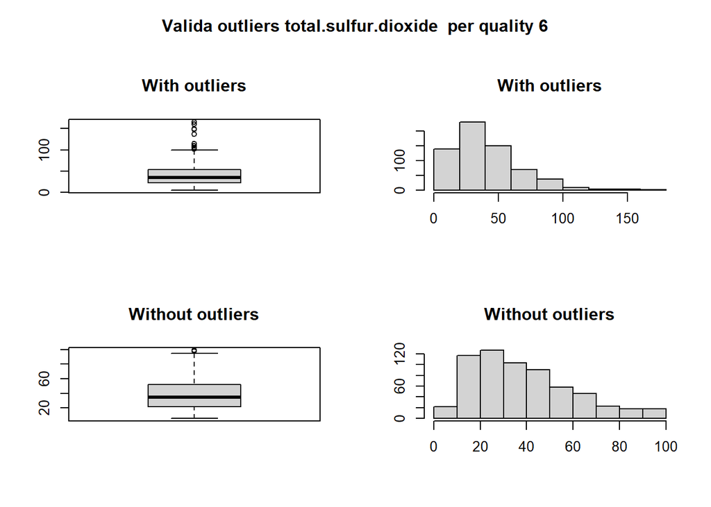

```
## Outliers identificats per la qualitat del vi: 6 :  15
## Proporció (%) de outliers: 2.4
## Mitja dels outliers: 123.73
## Mitja sense eliminar els outliers: 40.87
## Mitja eliminant outliers: 38.87
```

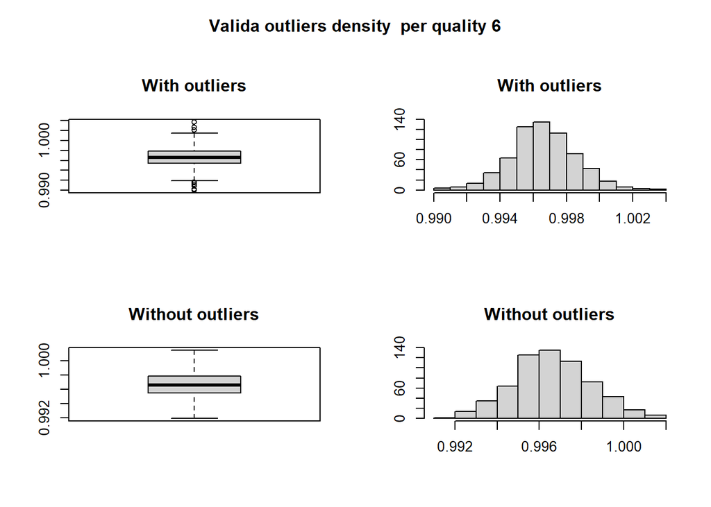

```
## Outliers identificats per la qualitat del vi: 6 :  14
## Proporció (%) de outliers: 2.2
## Mitja dels outliers: 1
## Mitja sense eliminar els outliers: 1
## Mitja eliminant outliers: 1
```

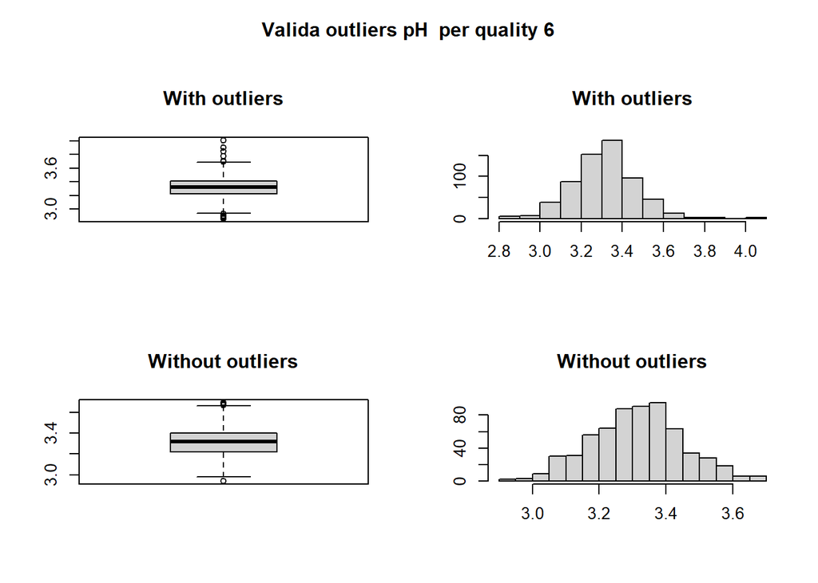

```
## Outliers identificats per la qualitat del vi: 6 :  14
## Proporció (%) de outliers: 2.2
## Mitja dels outliers: 3.37
## Mitja sense eliminar els outliers: 3.32
## Mitja eliminant outliers: 3.32
```

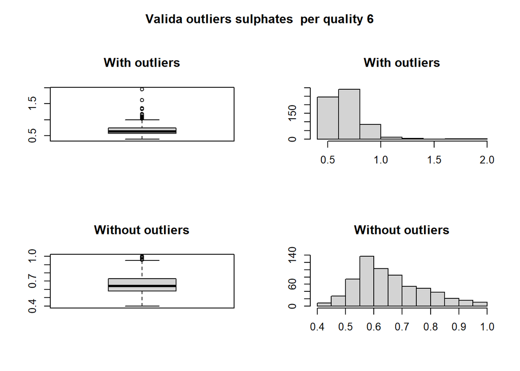

```
## Outliers identificats per la qualitat del vi: 6 :  16
## Proporció (%) de outliers: 2.6
## Mitja dels outliers: 1.28
## Mitja sense eliminar els outliers: 0.68
## Mitja eliminant outliers: 0.66
```

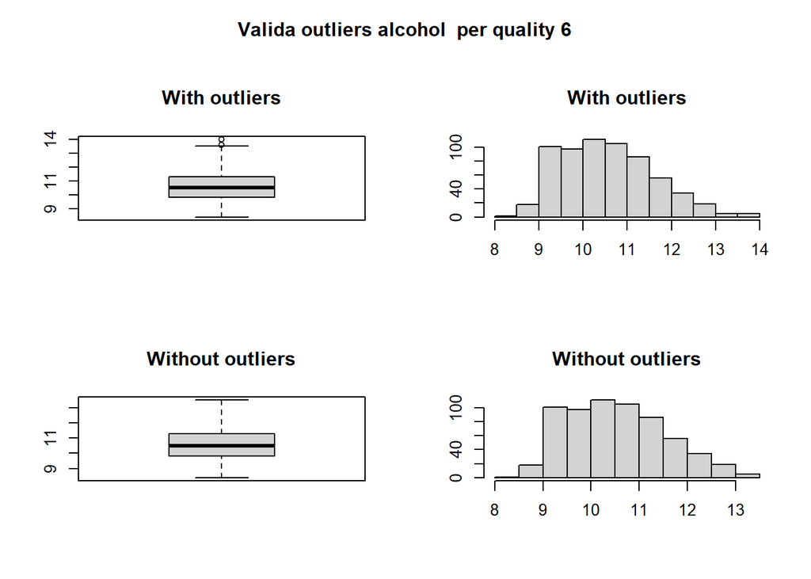

```
## Outliers identificats per la qualitat del vi: 6 :  5
## Proporció (%) de outliers: 0.8
## Mitja dels outliers: 13.92
## Mitja sense eliminar els outliers: 10.63
## Mitja eliminant outliers: 10.6
```

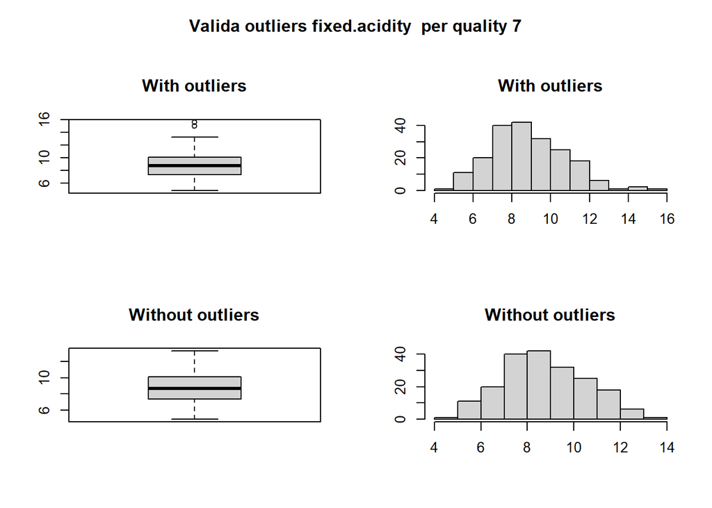

```
## Outliers identificats per la qualitat del vi: 7 :  3
## Proporció (%) de outliers: 1.5
## Mitja dels outliers: 15.2
## Mitja sense eliminar els outliers: 8.87
## Mitja eliminant outliers: 8.78
```

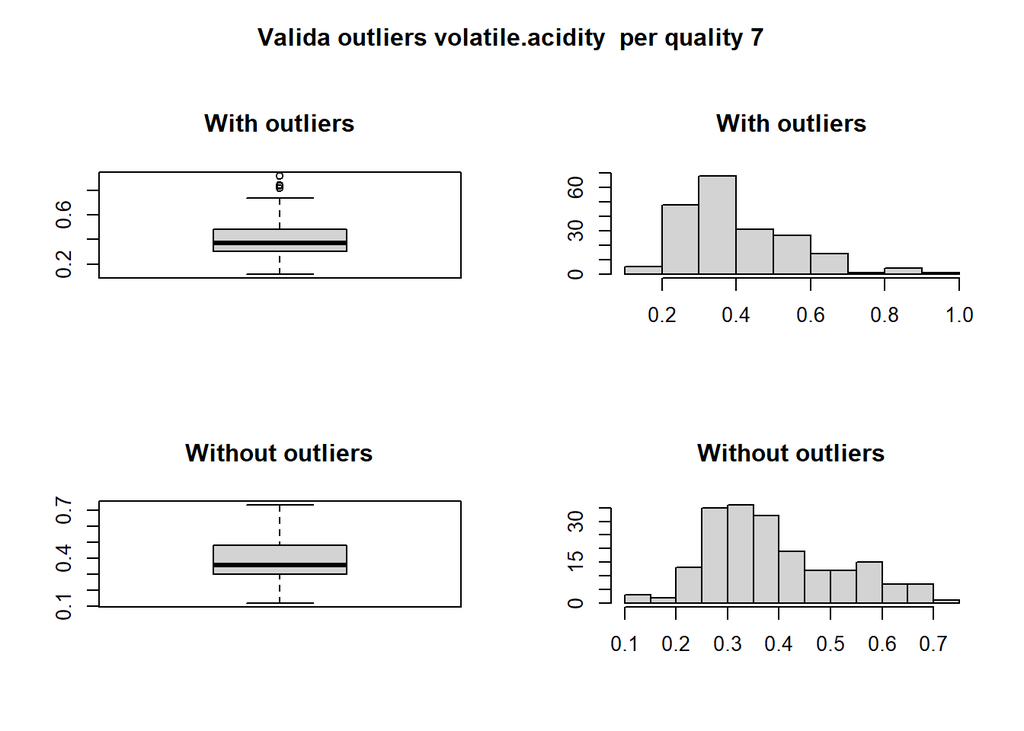

```
## Outliers identificats per la qualitat del vi: 7 :  5
## Proporció (%) de outliers: 2.6
## Mitja dels outliers: 0.85
## Mitja sense eliminar els outliers: 0.4
## Mitja eliminant outliers: 0.39
```

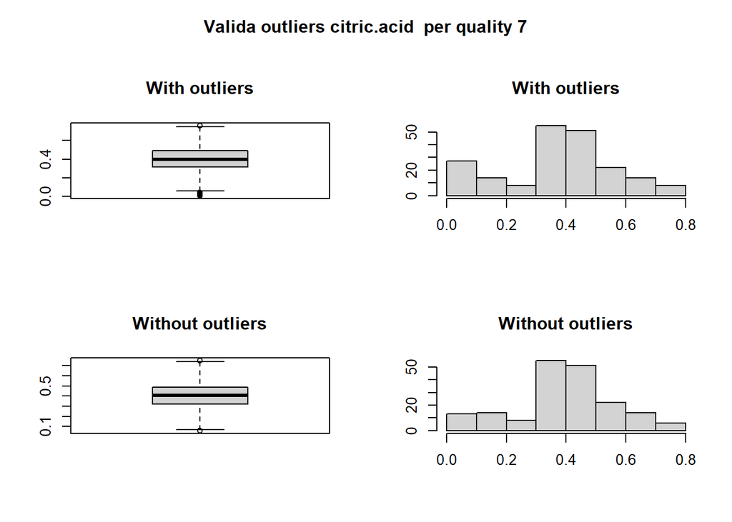

```
## Outliers identificats per la qualitat del vi: 7 :  16
## Proporció (%) de outliers: 8.7
## Mitja dels outliers: 0.11
## Mitja sense eliminar els outliers: 0.38
## Mitja eliminant outliers: 0.4
```

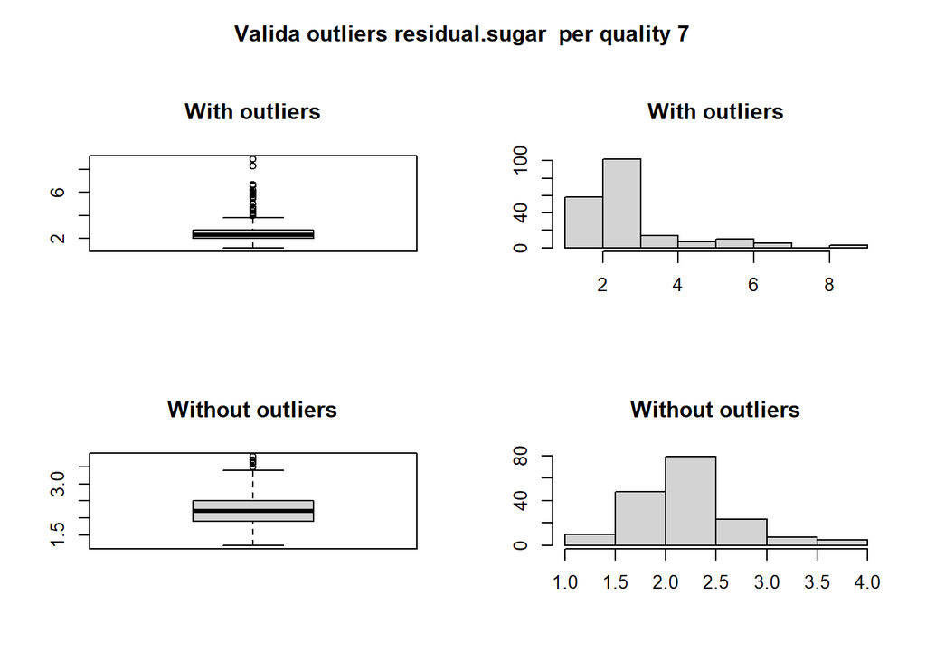

```
## Outliers identificats per la qualitat del vi: 7 :  27
## Proporció (%) de outliers: 15.7
## Mitja dels outliers: 5.75
## Mitja sense eliminar els outliers: 2.72
## Mitja eliminant outliers: 2.24
```

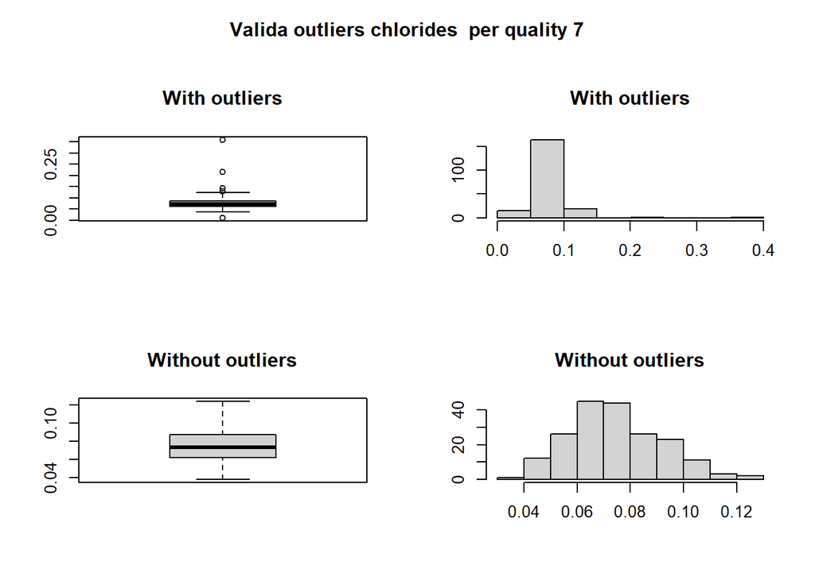

```
## Outliers identificats per la qualitat del vi: 7 :  6
## Proporció (%) de outliers: 3.1
## Mitja dels outliers: 0.14
## Mitja sense eliminar els outliers: 0.08
## Mitja eliminant outliers: 0.07
```

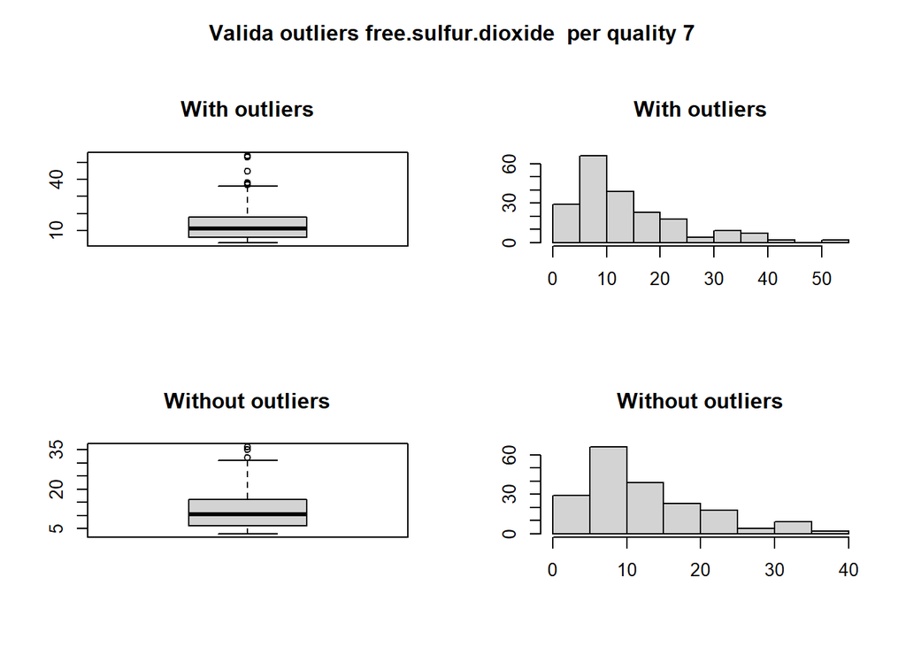

```
## Outliers identificats per la qualitat del vi: 7 :  9
## Proporció (%) de outliers: 4.7
## Mitja dels outliers: 42.78
## Mitja sense eliminar els outliers: 14.05
## Mitja eliminant outliers: 12.68
```

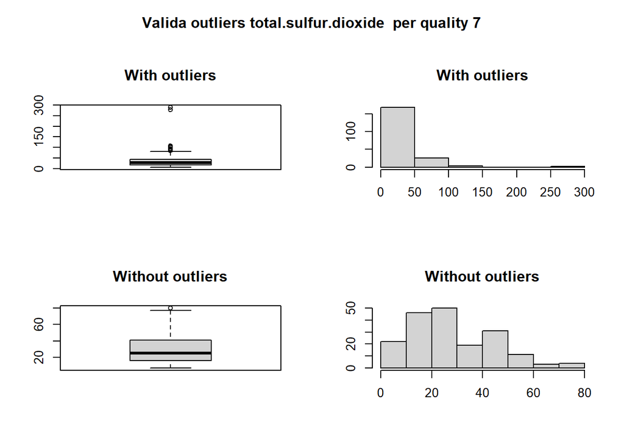

```
## Outliers identificats per la qualitat del vi: 7 :  13
## Proporció (%) de outliers: 7
## Mitja dels outliers: 123.85
## Mitja sense eliminar els outliers: 35.02
## Mitja eliminant outliers: 28.81
```

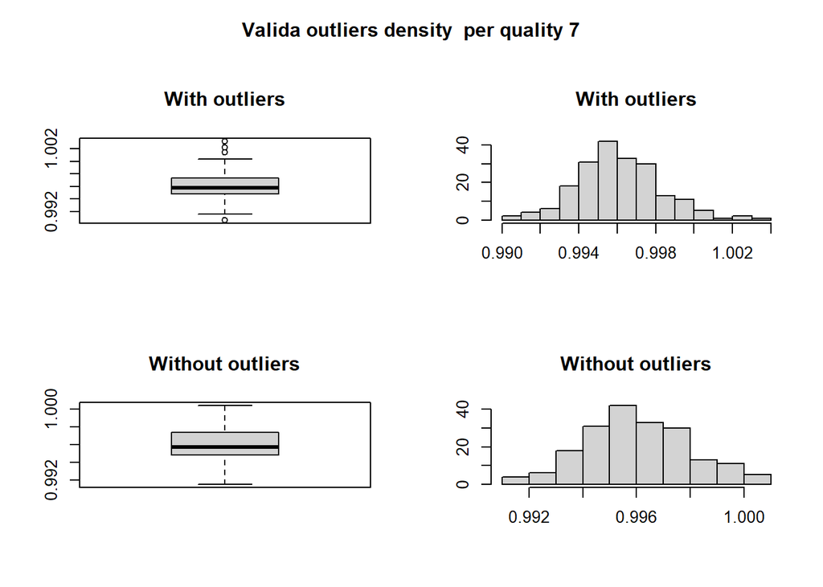

```
## Outliers identificats per la qualitat del vi: 7 :  6
## Proporció (%) de outliers: 3.1
## Mitja dels outliers: 1
## Mitja sense eliminar els outliers: 1
## Mitja eliminant outliers: 1
```

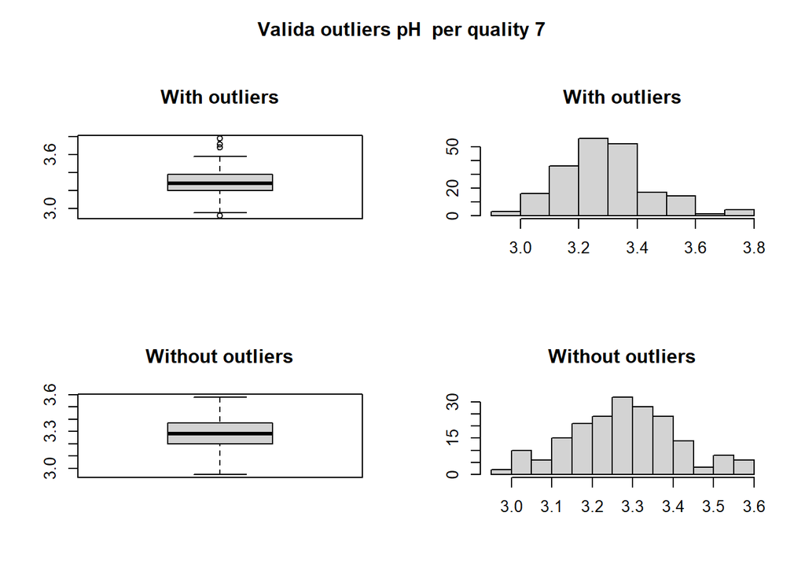

```
## Outliers identificats per la qualitat del vi: 7 :  6
## Proporció (%) de outliers: 3.1
## Mitja dels outliers: 3.58
## Mitja sense eliminar els outliers: 3.29
## Mitja eliminant outliers: 3.28
```

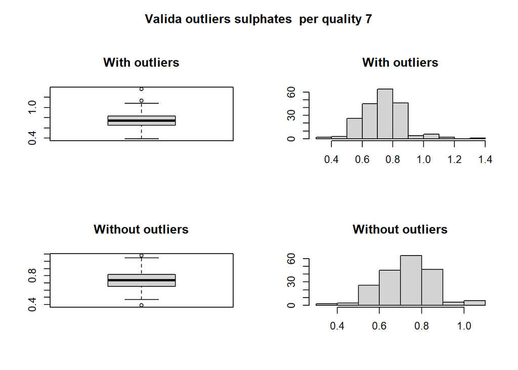

```
## Outliers identificats per la qualitat del vi: 7 :  3
## Proporció (%) de outliers: 1.5
## Mitja dels outliers: 1.21
## Mitja sense eliminar els outliers: 0.74
## Mitja eliminant outliers: 0.73
```

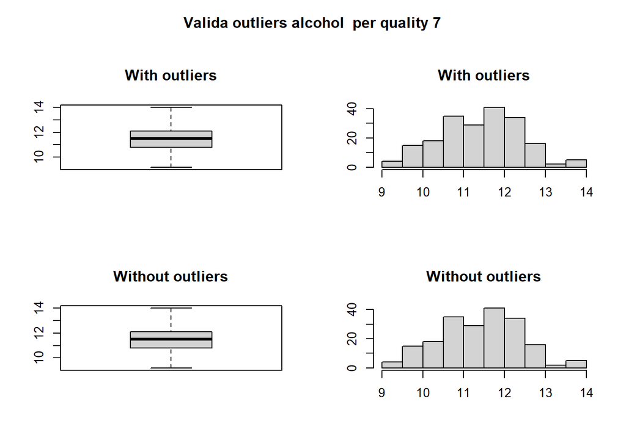

```
## Outliers identificats per la qualitat del vi: 7 :  0
## Proporció (%) de outliers: 0
## Mitja dels outliers: NaN
## Mitja sense eliminar els outliers: 11.47
## Mitja eliminant outliers: 11.47
```

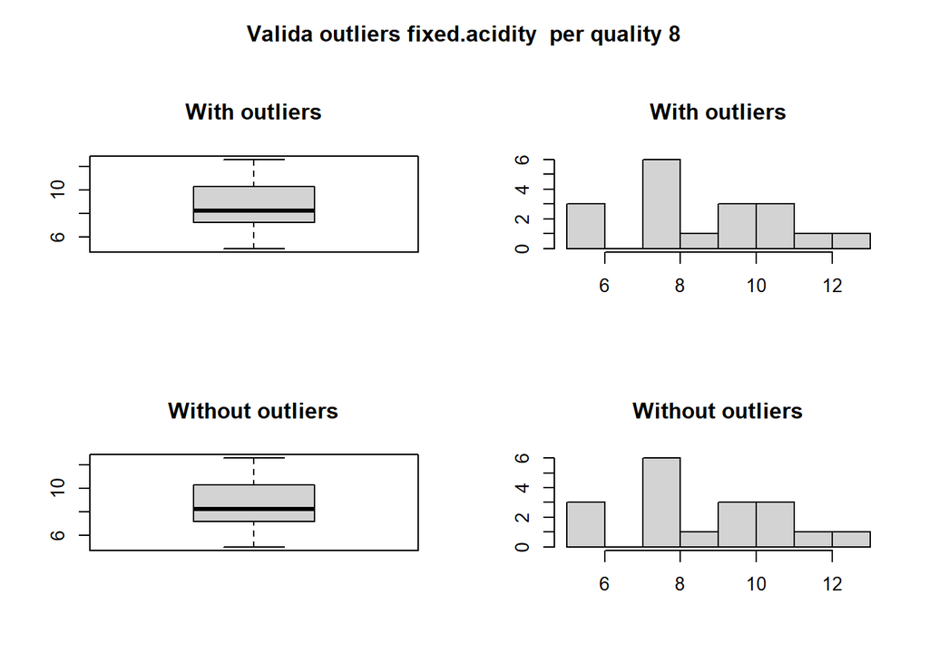

```
## Outliers identificats per la qualitat del vi: 8 :  0
## Proporció (%) de outliers: 0
## Mitja dels outliers: NaN
## Mitja sense eliminar els outliers: 8.57
## Mitja eliminant outliers: 8.57
```

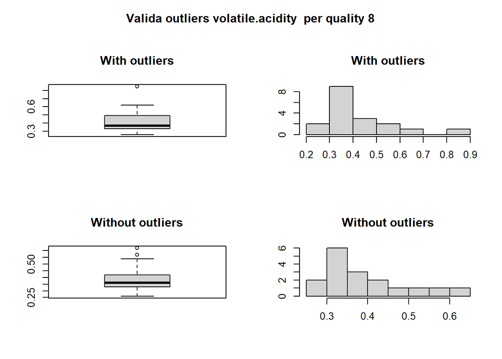

```
## Outliers identificats per la qualitat del vi: 8 :  1
## Proporció (%) de outliers: 5.9
## Mitja dels outliers: 0.85
## Mitja sense eliminar els outliers: 0.42
## Mitja eliminant outliers: 0.4
```

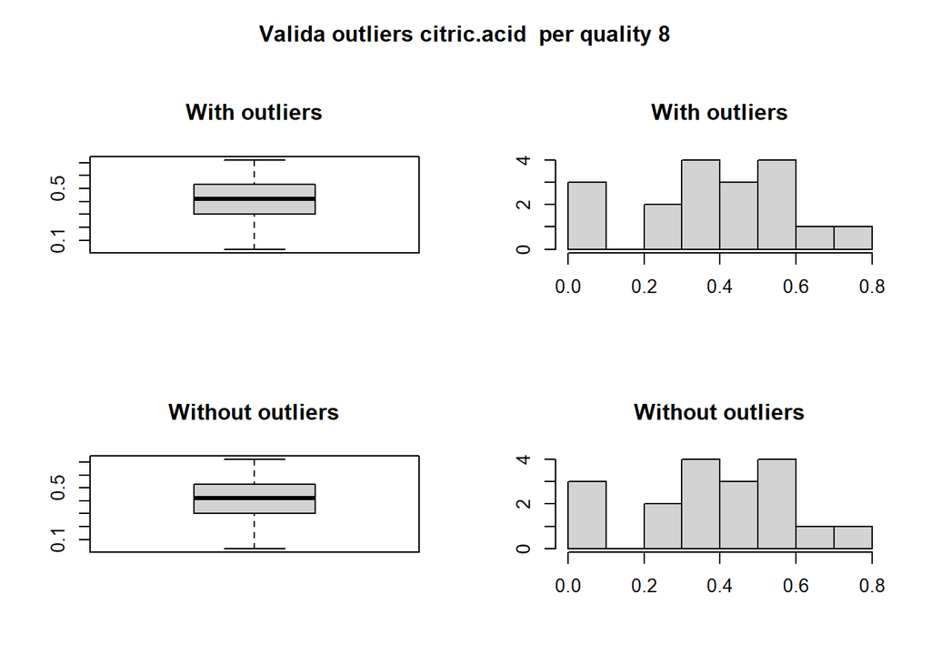

```
## Outliers identificats per la qualitat del vi: 8 :  0
## Proporció (%) de outliers: 0
## Mitja dels outliers: NaN
## Mitja sense eliminar els outliers: 0.39
## Mitja eliminant outliers: 0.39
```

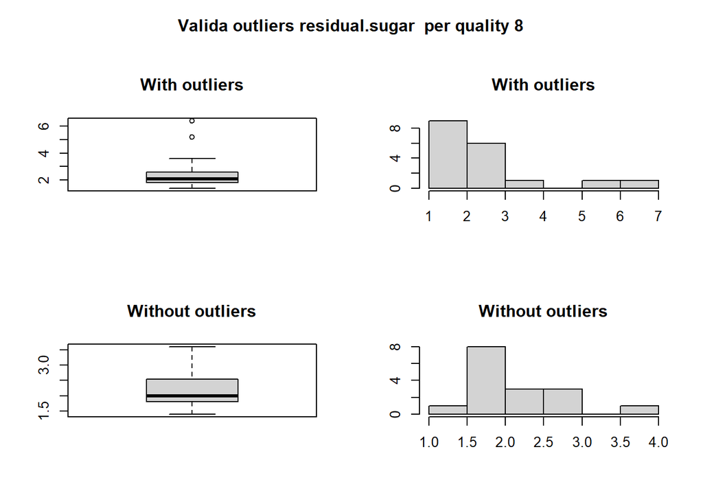

```
## Outliers identificats per la qualitat del vi: 8 :  2
## Proporció (%) de outliers: 12.5
## Mitja dels outliers: 5.8
## Mitja sense eliminar els outliers: 2.58
## Mitja eliminant outliers: 2.17
```

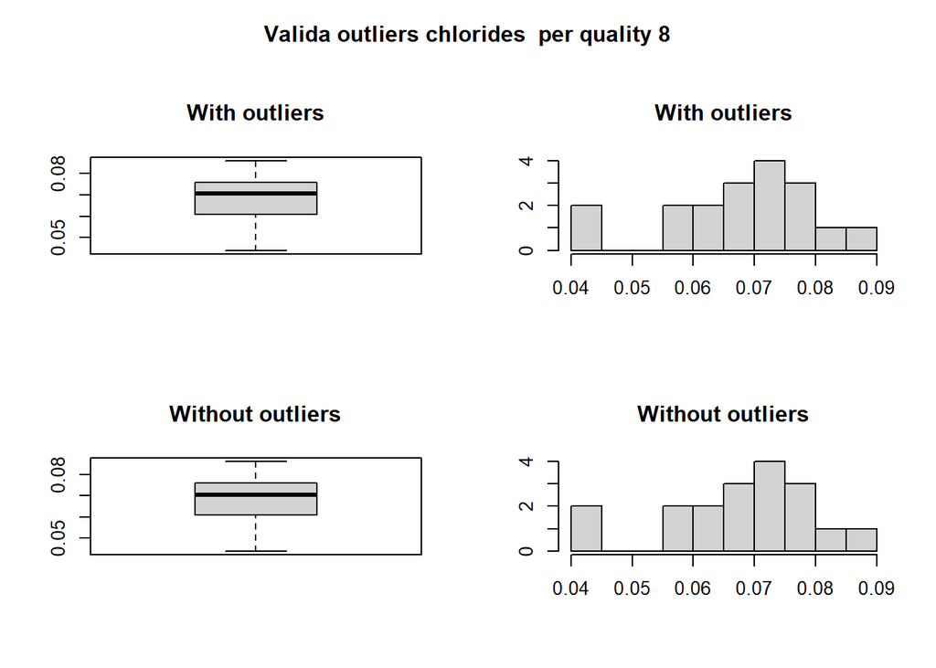

```
## Outliers identificats per la qualitat del vi: 8 :  0
## Proporció (%) de outliers: 0
## Mitja dels outliers: NaN
## Mitja sense eliminar els outliers: 0.07
## Mitja eliminant outliers: 0.07
```

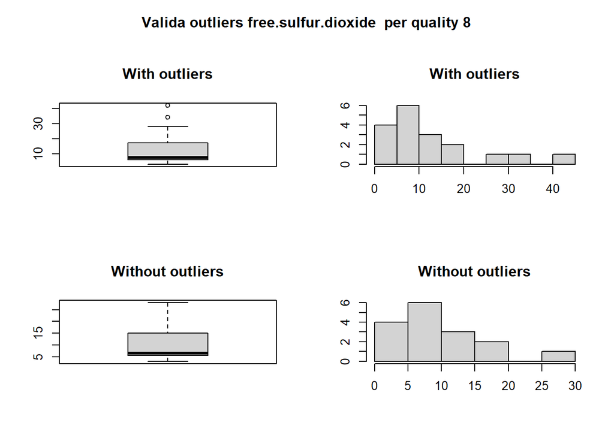

```
## Outliers identificats per la qualitat del vi: 8 :  2
## Proporció (%) de outliers: 12.5
## Mitja dels outliers: 38
## Mitja sense eliminar els outliers: 13.28
## Mitja eliminant outliers: 10.19
```

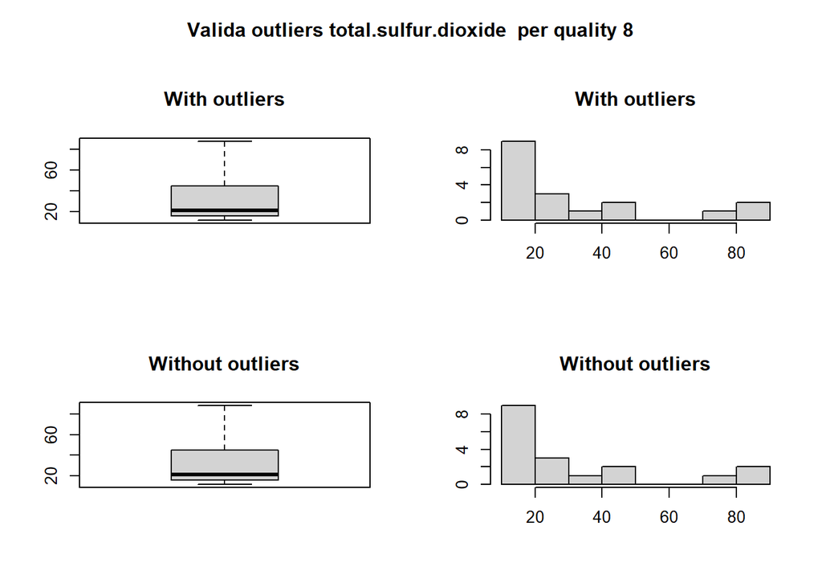

```
## Outliers identificats per la qualitat del vi: 8 :  0
## Proporció (%) de outliers: 0
## Mitja dels outliers: NaN
## Mitja sense eliminar els outliers: 33.44
## Mitja eliminant outliers: 33.44
```

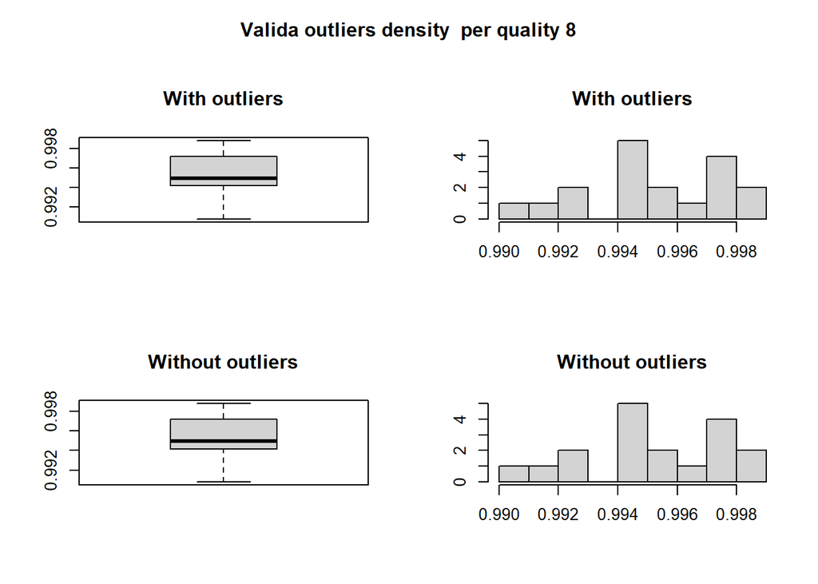

```
## Outliers identificats per la qualitat del vi: 8 :  0
## Proporció (%) de outliers: 0
## Mitja dels outliers: NaN
## Mitja sense eliminar els outliers: 1
## Mitja eliminant outliers: 1
```

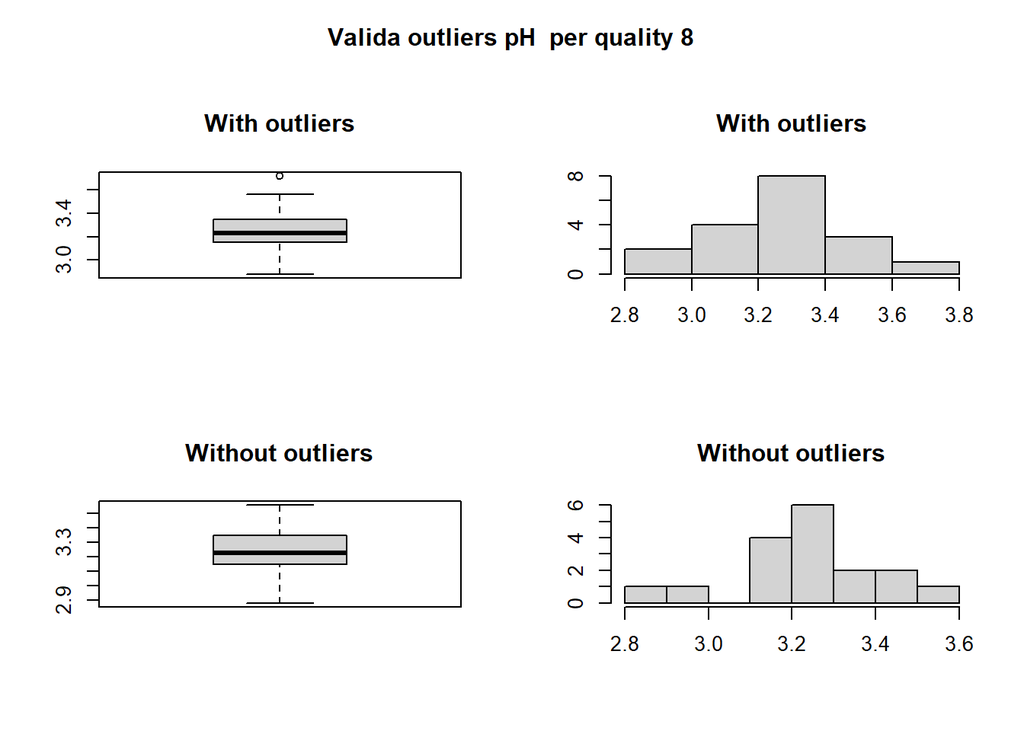

```
## Outliers identificats per la qualitat del vi: 8 :  1
## Proporció (%) de outliers: 5.9
## Mitja dels outliers: 3.72
## Mitja sense eliminar els outliers: 3.27
## Mitja eliminant outliers: 3.24
```

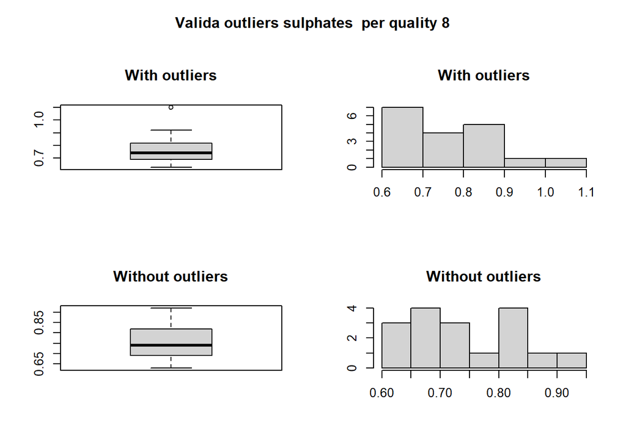

```
## Outliers identificats per la qualitat del vi: 8 :  1
## Proporció (%) de outliers: 5.9
## Mitja dels outliers: 1.1
## Mitja sense eliminar els outliers: 0.77
## Mitja eliminant outliers: 0.75
```

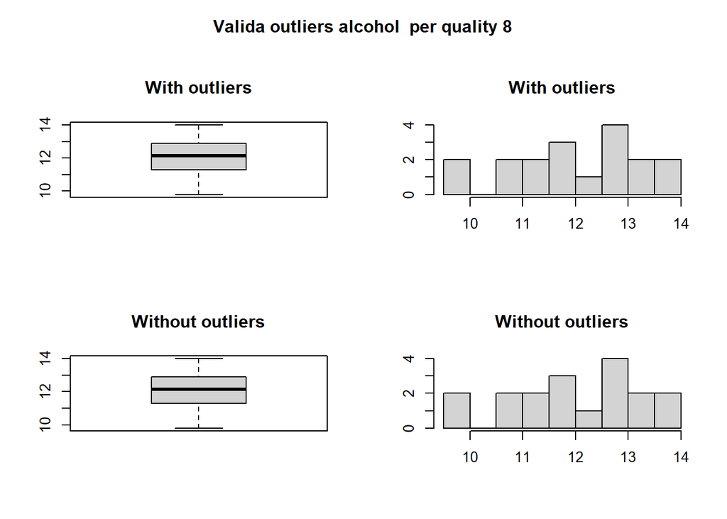

```
## Outliers identificats per la qualitat del vi: 8 :  0
## Proporció (%) de outliers: 0
## Mitja dels outliers: NaN
## Mitja sense eliminar els outliers: 12.09
## Mitja eliminant outliers: 12.09
```

```r
str(wine_red_x2)
```

```
## 'data.frame':    1599 obs. of  12 variables:
##  $ fixed.acidity       : num  11.6 10.4 7.4 10.4 8.3 7.6 6.8 7.3 7.1 6.7 ...
##  $ volatile.acidity    : num  0.58 0.61 1.18 0.44 1.02 ...
##  $ citric.acid         : num  0.66 0.49 0.05 0.42 0.02 0.05 0.05 0.05 0.05 0.02 ...
##  $ residual.sugar      : num  2.2 2.1 4.25 1.5 3.4 2.1 1.2 2.1 5.7 1.8 ...
##  $ chlorides           : num  0.074 0.2 0.097 0.145 0.084 0.137 0.267 0.061 0.082 0.078 ...
##  $ free.sulfur.dioxide : num  10 5 5 34 6 5 16 20 3 6 ...
##  $ total.sulfur.dioxide: num  47 16 14 48 11 9 29 49 14 12 ...
##  $ density             : num  1.001 0.999 0.997 0.998 0.999 ...
##  $ pH                  : num  3.25 3.16 3.63 3.38 3.48 3.5 3.32 3.31 3.4 3.55 ...
##  $ sulphates           : num  0.57 0.63 0.54 0.86 0.49 0.4 0.51 0.55 0.52 0.63 ...
##  $ alcohol             : num  9 8.4 10.7 9.9 11 10.9 9.8 9.7 10.2 9.95 ...
##  $ quality             : Factor w/ 6 levels "3","4","5","6",..: 1 1 1 1 1 1 1 1 1 1 ...
```

```r
str(wine_red_x3)
```

```
## 'data.frame':    1599 obs. of  12 variables:
##  $ fixed.acidity       : num  11.6 10.4 7.4 10.4 8.3 7.6 6.8 7.3 7.1 6.7 ...
##  $ volatile.acidity    : num  0.58 0.61 1.18 0.44 1.02 ...
##  $ citric.acid         : num  0.66 0.49 0.05 0.42 0.02 0.05 0.05 0.05 0.05 0.02 ...
##  $ residual.sugar      : num  2.2 2.1 4.25 1.5 3.4 2.1 1.2 2.1 5.7 1.8 ...
##  $ chlorides           : num  0.074 0.2 0.097 0.145 0.084 0.137 0.27 0.061 0.082 0.078 ...
##  $ free.sulfur.dioxide : num  10 5 5 34 6 5 16 20 3 6 ...
##  $ total.sulfur.dioxide: num  47 16 14 48 11 9 29 49 14 12 ...
##  $ density             : num  1.001 0.999 0.997 0.998 0.999 ...
##  $ pH                  : num  3.25 3.16 3.63 3.38 3.48 3.5 3.32 3.31 3.4 3.55 ...
##  $ sulphates           : num  0.57 0.63 0.54 0.86 0.49 0.4 0.51 0.55 0.52 0.63 ...
##  $ alcohol             : num  9 8.4 10.7 9.9 11 10.9 9.8 9.7 10.2 9.95 ...
##  $ quality             : Factor w/ 6 levels "3","4","5","6",..: 1 1 1 1 1 1 1 1 1 1 ...
```

Després de la imputació dels outliers, com s’ha explicat, amb la mitjana de cadascun dels nivells de qualitat i per cadascuna de les diferents variables, aquests son els resultats més destacables:

- Els valors atípics son 599 i es concentren en les categories 5 i 6 amb 467, el 78% dels total. Sens dubte perquè a aquestes qualitats es on es concentra la majoria de les observacions, el 82.45%.
- Les variables que més valors atípics acumulen son, per ordre: residual.sugar amb 155 (el 26% del total), chlorides amb 99 (el 17%) i sulphates amb 73 (el 12%). Les quals suposen el 55% del total.
- Per variables i categories, es residual.sugar en la 5 la que més valors extrems te, 66 (suposant l’11% del total). Seguida d’ella mateix per la categoria 6 amb 53 (9%) i sulphates en la categoria 5 amb 48 (8% del total).
- Observant els histogrames per cadascuna de les variables i per categories, es podria afirmar que després de la imputació dels valors atípics, les variables majoritàriament segueixen una distribució normal o homologables amb la normalitat. Exemples de normals en serien: chlorides, density i sulphates per quality 5; residual.sugar, chlorides, density i pH per quality 6; etc. Altres amb esbiaixat a la dreta serien: total.sulfur.dioxide per quality 4 i 6, citric.acid per quality 5, free.sulfur.dioxide per quality 5 i 7, etc. I amb cua llarga per la dreta: fixed.acidity, residual.sugar i alcohol per quality 5; sulphates per quality 6; etc.
- Resulten destacables els casos on amb la presència d’outliers no quedaba definida una distribució normal i imputant la mitjana de la respectiva categoria, esdevé normal. Es el cas de: residual.sugar, chlorides i sulphates tant per quality 5 i 6.

Finalitzat el procés de tractament d’outliers i reanomenat el dataset a wine_red_x3, es poden apreciar alguns canvis significatius:

```r
summary(wine_red_x3)
```

```
##  fixed.acidity   volatile.acidity  citric.acid     residual.sugar
##  Min.   : 4.60   Min.   :0.1200   Min.   :0.0100   Min.   :1.200
##  1st Qu.: 7.10   1st Qu.:0.3900   1st Qu.:0.1100   1st Qu.:1.900
##  Median : 7.90   Median :0.5200   Median :0.2600   Median :2.200
##  Mean   : 8.32   Mean   :0.5278   Mean   :0.2802   Mean   :2.539
##  3rd Qu.: 9.20   3rd Qu.:0.6400   3rd Qu.:0.4200   3rd Qu.:2.600
##  Max.   :15.20   Max.   :1.5800   Max.   :1.0000   Max.   :6.060
##    chlorides       free.sulfur.dioxide total.sulfur.dioxide    density
##  Min.   :0.03800   Min.   : 1.00       Min.   :  6.00       Min.   :0.9908
##  1st Qu.:0.07000   1st Qu.: 7.00       1st Qu.: 22.00       1st Qu.:0.9957
##  Median :0.07900   Median :14.00       Median : 38.00       Median :0.9968
##  Mean   :0.08736   Mean   :15.87       Mean   : 46.47       Mean   :0.9968
##  3rd Qu.:0.09100   3rd Qu.:21.00       3rd Qu.: 62.00       3rd Qu.:0.9979
##  Max.   :0.27000   Max.   :53.00       Max.   :155.00       Max.   :1.0015
##        pH          sulphates         alcohol      quality
##  Min.   :2.880   Min.   :0.3300   Min.   : 8.40   3: 10
##  1st Qu.:3.210   1st Qu.:0.5500   1st Qu.: 9.50   4: 53
##  Median :3.310   Median :0.6200   Median :10.20   5:681
##  Mean   :3.311   Mean   :0.6582   Mean   :10.42   6:638
##  3rd Qu.:3.400   3rd Qu.:0.7300   3rd Qu.:11.10   7:199
##  Max.   :3.750   Max.   :1.2800   Max.   :14.00   8: 18
```

- S’han reduït les mitjanes de fixed.acidity, volatile.acidity, citric.acid, residual.sugar, chlorides, free.sulfur.dioxide, total.sulfur.dioxide, density, sulphates i alcohol. Només ha pujat la de pH.
- El valor de la mediana també s’ha reduït per fixed.acidity, citric.acid, residual.sugar, chlorides, free.sulfur.dioxide, total.sulfur.dioxide, density, sulphates i per alcohol. No s’ha vist alterada per volatile.acidity i ha pujat per pH.
- Els valors mínims han augmentat per fixed.acidity, residual.sugar, chlorides, density, pH i alcohol. I romanen igual volatile.acidity, citric.acid, free.sulfur.dioxide, total.sulfur.dioxide i sulphates.
- Els valors màxims s’han reduït per totes les variables.
- El primer quartil s’ha reduït per citric.acid, chlorides i density. Sense alteració per a fixed.acidity, volatile.acidity, residual.sugar, free.sulfur.dioxide, total.sulfur.dioxide, sulphates i alcohol. I només ha augmentat per pH.
- I el tercer quartil ha disminuït per fixed.acidity, volatile.acidity, citric.acid, residual.sugar, chlorides, free.sulfur.dioxide, total.sulfur.dioxide, density, sulphates i alcohol. I no ha canviat per pH.

*Bibliografia*:

http://ai.fon.bg.ac.rs/wp-content/uploads/2017/09/WholesaleCustomersClustering_handout.pdf

https://rpubs.com/YasmeenMubarak/462147

https://www.r-bloggers.com/2016/04/identify-describe-plot-and-remove-the-outliers-from-the-dataset/

# 4.- Anàlisi de les dades.

## 4.1.- Selecció dels grups de dades que es volen analitzar/comparar (planificació dels anàlisis a aplicar).

Per seleccionar els grups de dades que son més interesant per analitzar, cal centrar-se en les variables que tenen més relació amb la qualitat del vi. Primer es crearà una comparació de mitjana per veure la relació entre les diferents propietats del vi i la seva qualitat.

Desprès es crearà una matriu formada per la mitjana de les diferents variables, agruapdes per qualitat. On a les columnes es trobarà les diferents variables i les files correspondran a cada grup de qualitat del vi.

A continuació es ralitzarà una representació gràfica de la correlació entre els diferents parells de variables del *dataset*, on es podrà veure els que estan més relacionats entre ells.

Finalment es mostrarà un mapa de calor, al que se li passarà la matriu numèrica creada previament.

```r
# Crearem una copia del dataset i la variable quality es passarà a numèrica
wine_red_x31 <- wine_red_x3
wine_red_x31$quality <- as.numeric(as.factor(wine_red_x3$quality))
str(wine_red_x31)
```

```
## 'data.frame':    1599 obs. of  12 variables:
##  $ fixed.acidity       : num  11.6 10.4 7.4 10.4 8.3 7.6 6.8 7.3 7.1 6.7 ...
##  $ volatile.acidity    : num  0.58 0.61 1.18 0.44 1.02 ...
##  $ citric.acid         : num  0.66 0.49 0.05 0.42 0.02 0.05 0.05 0.05 0.05 0.02 ...
##  $ residual.sugar      : num  2.2 2.1 4.25 1.5 3.4 2.1 1.2 2.1 5.7 1.8 ...
##  $ chlorides           : num  0.074 0.2 0.097 0.145 0.084 0.137 0.27 0.061 0.082 0.078 ...
##  $ free.sulfur.dioxide : num  10 5 5 34 6 5 16 20 3 6 ...
##  $ total.sulfur.dioxide: num  47 16 14 48 11 9 29 49 14 12 ...
##  $ density             : num  1.001 0.999 0.997 0.998 0.999 ...
##  $ pH                  : num  3.25 3.16 3.63 3.38 3.48 3.5 3.32 3.31 3.4 3.55 ...
##  $ sulphates           : num  0.57 0.63 0.54 0.86 0.49 0.4 0.51 0.55 0.52 0.63 ...
##  $ alcohol             : num  9 8.4 10.7 9.9 11 10.9 9.8 9.7 10.2 9.95 ...
##  $ quality             : num  1 1 1 1 1 1 1 1 1 1 ...
```

Es calcula la matriu de correlacions entre les diferents variables, la qual cosa donarà una millor comprensió de com les entitats es correlacionen entre si i permetrà veure quines juguen un paper més important en la decisió de la qualitat del vi.

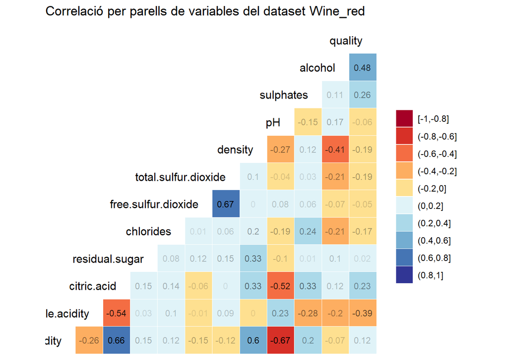

```r
ggcorr(wine_red_x31, nbreaks = 10, palette = "RdYlBu", geom = "tile", label = TRUE, label_size = 3, label_round = 2, label_alpha = TRUE, hjust = 1, size = 4, color = "black") + labs(title = "Correlació per parells de variables del dataset Wine_red")
```

A partir d’aquesta matriu es veuen algunes correlacions:

- Algunes òbvies, com entre els atributs *pH* i *fixed.acidity*, que tenen una correlació negativa relativament alta. Això s’explica per què un vi té un pH entre 2.8 i 4. Quan té el pH de 2.8 es extremadament àcid mentre que amb un pH de 4 es pla i no te acidesa.
- També es pot observar una correlació positiva relativament alta entre *fixed.acidity* i *citric.acidity*, així com entre *free.sulfur.dioxide* i *total.sulfur.dioxide*.
- La densitat té una forta correlació positiva amb *fixed.acidity*, mentre que té una forta correlació negativa amb *alcohol*.
- Destaca la correlació positiva relativament alta entre la presencia d’*alcohol* i *quality*.
- Respecte a *quality*, s’observa que aproximadament la meitad de les variables es correlacionen positivament amb ella, mentre que l’altre meitad es correlacionen negativament. D’entre totes les variables se seleccionaran pel seu estudi les que tinguin nombres més grans, ja que son les que donen més informació. Concretament les que tinguin un valor més gran de 0.2. Aquestes característiques corresponen a *alcohol*, *sulphates*, *citric.acid* i *volatile.acidity*.

Es realitza un boxplot per cada característica del vi seleccionat per comparar amb els diferents grups de qualitat.

*alcohol*

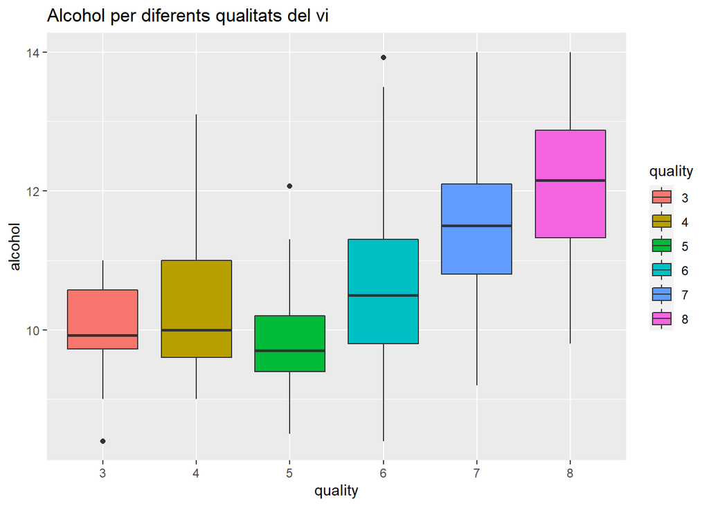

```r
ggplot(data = wine_red_x3, aes(y = alcohol , x = quality, fill= quality)) + geom_boxplot() + ggtitle("Alcohol per diferents qualitats del vi")
```

A partir del *boxplot* es pot veure que els vins que tenen menys alcohol tenen pitjor qualificació, valors 3, 4 i 5. Mentre que els que tenen més alcohol obtenen un valor més alt en la qualitat. Per tant, hi ha un augment de la qualitat del vi quan es produeix un augment de l’acohol. La qualitat del vi està idrectament relacionada amb la quantitat d’alcohol del vi. Els punts que es troben fora del bigotis (linies que s’estenen des de la caixa rectangular) corresponen als outliers.

*sulphates*

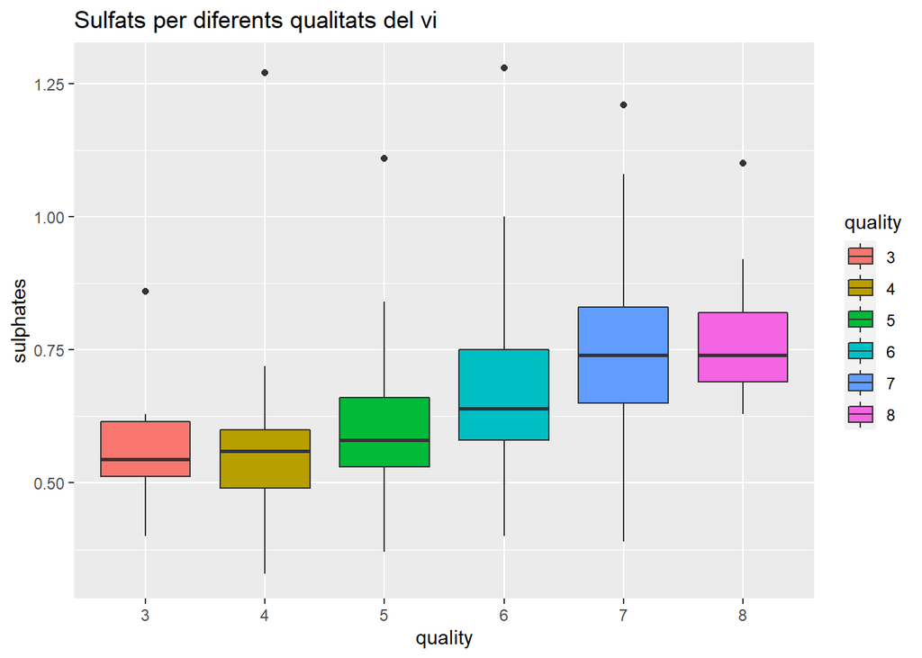

```r
ggplot(data = wine_red_x3, aes(y = sulphates , x = quality, fill=quality)) + geom_boxplot() + ggtitle("Sulfats per diferents qualitats del vi")
```

Pel cas de *sulphates*, els *boxplots* mostres una relació linialment positiva amb *quality*. Així, el fet de tenir majors quantitats de *sulphates* sembla que obtenen una major qualificació de la qualitat del vi.

*citric.acid*

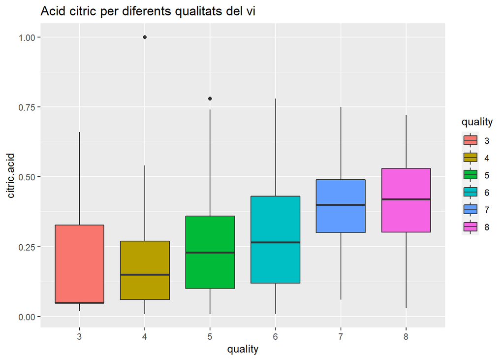

```r
ggplot(data = wine_red_x3, aes(y = citric.acid , x = quality, fill=quality)) + geom_boxplot() + ggtitle("Acid citric per diferents qualitats del vi")
```

Aquest cas es semblant al del *sulphates*, els *boxplots* mostren una relació linialment positiva amb *quality* del vi. Així, el fet de tenir majors quantitats de *citric.acid* sembla que obtenen una major qualificació de la qualitat del vi.

*volatile.acidity*

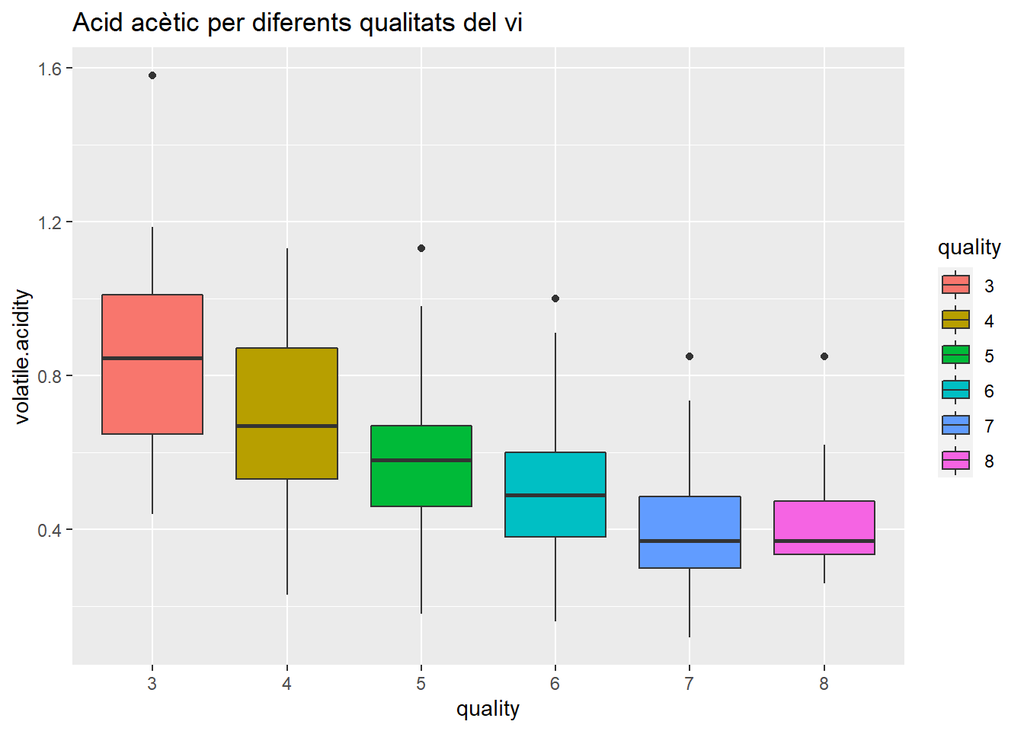

```r
ggplot(data = wine_red_x3, aes(y = volatile.acidity , x = quality, fill=quality)) + geom_boxplot() + ggtitle("Acid acètic per diferents qualitats del vi")
```

En el cas de *volatile.acidity* s’observa que quan menys presència hi ha, el valor de *quality* es més alt. I quant més *volatile.acidity* conté, menys està valorat el vi.

Creació d’una matriu amb les mitjanes de cada variable del *dataset* agrupades per la variable *quality*.

```r
# Preparació d'una matriu amb les mitjanes per a cada tipus de qualitat:
# Realitzem split per agrupar per cada valor de la variable quality
wine_quality=split(wine_red_x3, wine_red_x3$quality)

wine_matrix=NULL
for (i in seq(3:8)){
    wines= data.frame(wine_quality[i])
    mitjanes=colMeans(wines[,1:11])
    wine_matrix=rbind(wine_matrix,mitjanes)
}
# Afegim capçaleres a les columnes
colnames(wine_matrix)=colnames(wine_red_x3[1:11])
# Afegim nom a les files, on cadascuna correspon a una qualitat
#row.names(wine_matrix)=c("Qualitat 3","Qualitat 4","Qualitat 5","Qualitat 6","Qualitat 7", "Qualitat 8")
row.names(wine_matrix) <- paste("Qualitat ", 3:8)
wine_matrix
```

```
##             fixed.acidity volatile.acidity citric.acid residual.sugar
## Qualitat  3      8.360000        0.8845000   0.1860000       2.635000
## Qualitat  4      7.779057        0.6939623   0.2000000       2.694717
## Qualitat  5      8.167401        0.5771072   0.2532599       2.528796
## Qualitat  6      8.347147        0.4974687   0.2830094       2.477273
## Qualitat  7      8.872362        0.4039447   0.3796482       2.720352
## Qualitat  8      8.566667        0.4233333   0.3911111       2.577778
##              chlorides free.sulfur.dioxide total.sulfur.dioxide   density
## Qualitat  3 0.12280000            11.00000             24.90000 0.9974640
## Qualitat  4 0.09045283            12.26396             36.24528 0.9965189
## Qualitat  5 0.09276358            16.98385             56.51395 0.9971922
## Qualitat  6 0.08471003            15.71157             40.86983 0.9967203
## Qualitat  7 0.07644221            14.04533             35.02035 0.9961531
## Qualitat  8 0.06844444            13.27778             33.44444 0.9952122
##                   pH sulphates   alcohol
## Qualitat  3 3.398000 0.5700000  9.955000
## Qualitat  4 3.381509 0.5967925 10.265094
## Qualitat  5 3.304978 0.6211601  9.899486
## Qualitat  6 3.317994 0.6752665 10.629519
## Qualitat  7 3.290603 0.7413065 11.465913
## Qualitat  8 3.267222 0.7677778 12.094444
```

A continuació es farà la representació d’una mapa de calor, amb la funció *pheatmap*, per visualitzar dades quantitatives en dues dimensions, al que se li pasarà una matriu numèrica que contindrà els valors que es traçaran. Es tracta d’un model no-supervisat que permet definir *clusters* i visualitzar patrons. A banda d’estar basat en la distància.

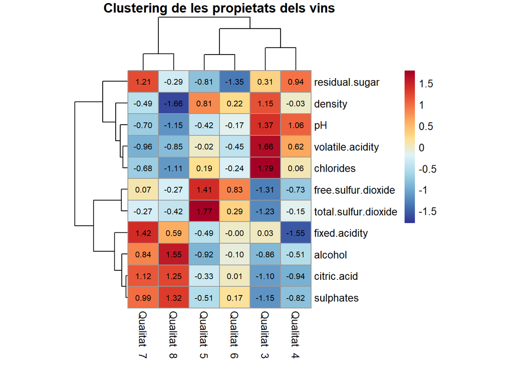

```r
# El mapa de calor ens permetrà trobar patrons per cada grup de qualitat de vi.
# Es mostraran els valors dins de cada cel·la.
# Es visualitzarà el dendograma de files, on es mostren els clusters creats entre les variables de les propietats dels vins i el dendograma de columnes on realitza els clusters agrupant per qualitats del vi.
heatmap <- pheatmap(as.matrix(t(wine_matrix)), display_numbers = TRUE,  number_color = "black",
         fontsize_number = 8, color = colorRampPalette(rev(brewer.pal(n = 10, name ="RdYlBu")))(100), scale = "row", cluster_rows = TRUE, cluster_cols = T, clustering_distance_cols = "euclidean", clustering_method = "ward.D2", fontsize = 10 , main = "Clustering de les propietats dels vins", show_rownames = T, cellwidth = 30)
```

Observant el mapa de calor es pot veure algun patró com el cas dels vins de qualitat més alta. On s’aprecia que tenen un valor més alt d’*alcohol*, *citric.acid*, *sulphates* i *fixed.acidity*. Mentre que els vins de baixa qualitat tenen valors més alts de *residual.sugar*, *density*, *pH*, *volatile.acidity* i *chlorides*. El vins de qualitat mitja tenen uns patrons elevats de sofre (*free.sulfur.dioxide* i *total.sulfur.dioxide*) i per la resta de variables tenen uns valors intermedis.

Aquest algorisme de mapa de calor també genera dendogrames, que en aquest cas es mostren els que corresponen a les columnes (pels grups de qualitat) i a les files (per les diferents variables). Aquests descriuen la proximitat entre les mostres basats en la distància euclídea. En aquest cas, tenim un *cluster* que agrupa els vins de qualitat 7 i 8, que serien els superiors. Un altre que agrupa els vins de qualitat 5 i 6 i un tercer *cluster* que agrupa els de qualitat 3 i 4 corresponen als vins de menys qualitat. Aquests *clusters* estarien agrupats en funció de les propietats fisicoquímiques de les diferents variables.

*Bibliografia*:

http://briatte.github.io/ggcorr/

https://r-charts.com/correlation/pheatmap/

https://datavizpyr.com/heatmaps-in-r-with-pheatmap-package/

https://betaeconomia.blogspot.com/2020/02/analisis-de-correlacion-en-r.html

https://datauab.github.io/red_wine_quality/#:~:text=4.%20Data%20Cleaning%20and%20Checking%20%C2%B6%20%20,%20%201.9%20%206%20more%20rows%20

https://www.aprenderdevino.es/ph-y-vino/#:~:text=El%20pH%20de%20la%20mayor%C3%ADa%20de%20los%20vinos,torno%20a%204%20es%20plano%2C%20carente%20de%20acidez.

https://www.kaggle.com/sachinrajput17/red-wine-quality

## 4.2.- Comprovació de la normalitat i homogeneïtat de la variància.

**Normalitat**

Per comprovar la normalitat es visualitzarà primer els histogrames de freqüència per cada atribut, la qual cosa permetrà verificar si les dades segueixen una distribució gaussiana. També es generaran els gràfics quantil-quantil (*Q-Q*) que permetran comparar la distribució dels valors respecte als d’una població normal.

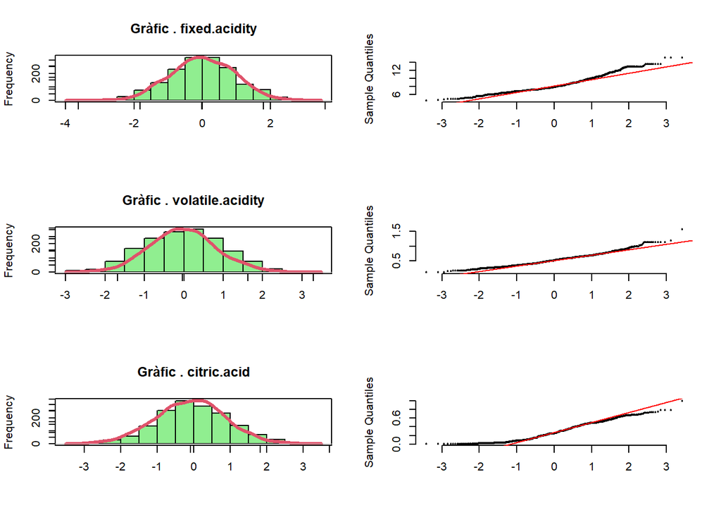

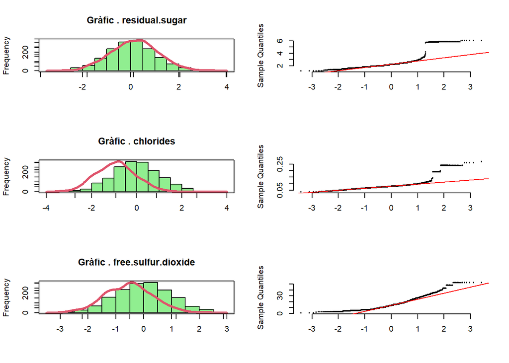

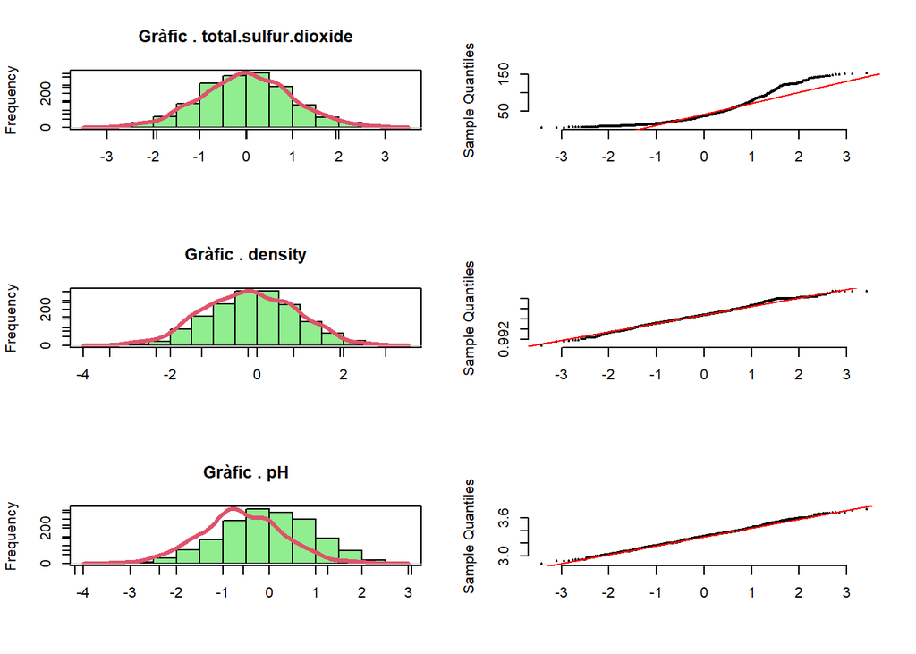

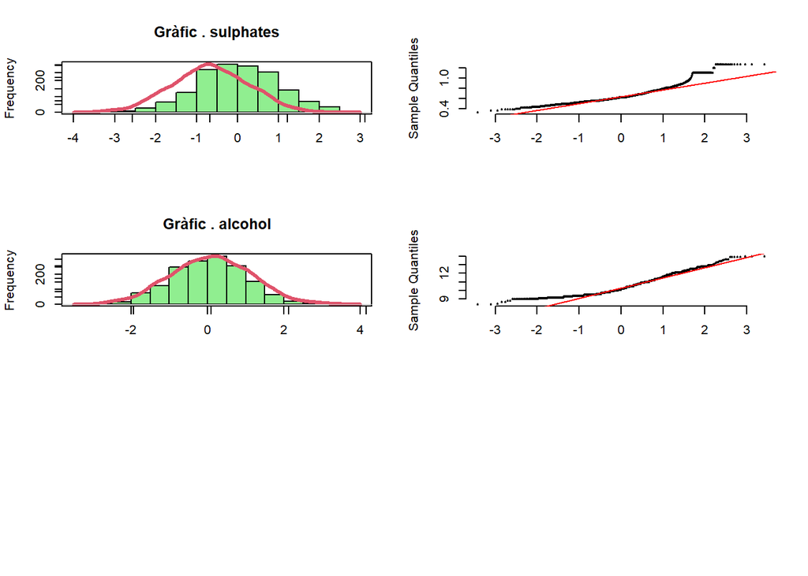

```r
# Comprovació de la distribució normal

# Inicialització del Dataframe
normalitat=NULL
# Fixem el format dels gràfics:
par(mfrow=c(3,2))
# Seguiment de les columnes del dataset wine_red:
for (i in (1:11)){
  # Histogrames de freqüència amb la funció density:
  hist(rnorm(wine_red_x3[,i]),main=paste("Gràfic", ".",colnames(wine_red_x3)[i]),xlab= "",col="lightgreen")
  par(new=T)
  plot(density(rnorm(wine_red_x3[,i])),col=2,lwd=3,main='',sub='',xlab='',ylab='',labels=FALSE)
  # Preparar gràfics de quantils amb les dades de cada variable:
  qqnorm(wine_red_x3[,i],pch=19,frame=FALSE,cex=0.3,main="",xlab= "")
  # Representar la líniea que adoptaria una població completament normal:
  qqline(wine_red_x3[,i], col = "red", lwd = 1)
}
```

**Homogeneitat de la variància**

Es verifica a continuació l’**homogeneïtat de la variança**, es a dir, l’**homoscedasticitat**. Es farà servir la funció *var.test()* que permetrà aplicar el **test de la F** d’*Snedecor* pel següent contrast d’hipòtesis:

$H_0: \sigma_A=\sigma_B$

$H_1: \sigma_a\neq\sigma_B$

Prenent la diagonal superior de la matriu resultant, a la taula a sota, s’observa que en tots el casos els *p-values* son menors al nivell de significança ($\alpha = 0.05$), menys per les variables *volatile.acidity* i *citric.acid* que es major, 0.279. La qual cosa voldría dir que s’hauria de rebutjar la hipòtesi nul·la d’igualtat de variàncies per tots els parells de variables menys per *volatile.acidity* i *citric.acid*, on no es podria rebutjar la hipòtesi nul·la d’igualtat de variàncies. Es a dir, només per a questes dues variables es podria assumir homoscedasticitat.

```r
# Igualtat de variàncies: homoscedasticitat

# Dataframe on es guarden els resultats:
homoscedasticitat=NULL
# For loop que recorre totes les columnes dues vegades:
for (i in (1:11)){
  for (j in (1:11)){
  # var.test() en forma de vis-a-vis (pairwise):
  homo=var.test(wine_red_x3[,i], wine_red_x3[,j], alternative = c("two.sided"))$p.value
  homoscedasticitat=cbind(homoscedasticitat, c(homo))
  }
}
# Arranjament del dataframe:
homoscedasticitat=round(matrix(unlist(homoscedasticitat), ncol = 11, byrow=T),3)
colnames(homoscedasticitat)=colnames(wine_red_x3[1:11])
row.names(homoscedasticitat)=colnames(wine_red_x3[1:11])
# Considerem la matriu superior:
homoscedasticitat[lower.tri(homoscedasticitat)]=NA
# Matriu diagonal de p-valors per al test d'homoscedasticitat aplicat a les propietats del vi
homoscedasticitat
```

```
##                      fixed.acidity volatile.acidity citric.acid residual.sugar
## fixed.acidity                    1                0       0.000              0
## volatile.acidity                NA                1       0.279              0
## citric.acid                     NA               NA       1.000              0
## residual.sugar                  NA               NA          NA              1
## chlorides                       NA               NA          NA             NA
## free.sulfur.dioxide             NA               NA          NA             NA
## total.sulfur.dioxide            NA               NA          NA             NA
## density                         NA               NA          NA             NA
## pH                              NA               NA          NA             NA
## sulphates                       NA               NA          NA             NA
## alcohol                         NA               NA          NA             NA
##                      chlorides free.sulfur.dioxide total.sulfur.dioxide density
## fixed.acidity                0                   0                    0       0
## volatile.acidity             0                   0                    0       0
## citric.acid                  0                   0                    0       0
## residual.sugar               0                   0                    0       0
## chlorides                    1                   0                    0       0
## free.sulfur.dioxide         NA                   1                    0       0
## total.sulfur.dioxide        NA                  NA                    1       0
## density                     NA                  NA                   NA       1
## pH                          NA                  NA                   NA      NA
## sulphates                   NA                  NA                   NA      NA
## alcohol                     NA                  NA                   NA      NA
##                      pH sulphates alcohol
## fixed.acidity         0         0       0
## volatile.acidity      0         0       0
## citric.acid           0         0       0
## residual.sugar        0         0       0
## chlorides             0         0       0
## free.sulfur.dioxide   0         0       0
## total.sulfur.dioxide  0         0       0
## density               0         0       0
## pH                    1         0       0
## sulphates            NA         1       0
## alcohol              NA        NA       1
```

*Bibliografia*:

https://rpubs.com/phobos/TLC

https://stackoverflow.com/questions/16702137/remove-y-label-from-plot-in-r

https://stackoverflow.com/questions/1154242/remove-plot-axis-values

## 4.3.- Aplicació de proves estadístiques per comparar els grups de dades. En funció de les dades i de l’objectiu de l’estudi, aplicar proves de contrast d’hipòtesis, correlacions, regressions, etc. Aplicar almenys tres mètodes d’anàlisi diferents.

A partir d’aquest *dataset* es poden obtenir interessants modelitzacions relacionades amb la qualitat del vi per donar resposta a les preguntes plantejades a l’apartat 1. Aquí s’han desenvolupat aquestes: un primer model de regressió lineal per poder fer prediccions dels components que determinaran la qualitat del vi. Un segon, molt relacionat amb el primer, de regressió logística per predir si un vi serà de qualitat o no. Un tercer model d’agregació per determinar si les diferents qualitats del vi s’han establert de forma correcta o les dades presenten agrupacions diferents. I un darrer model de classificació, per obtenir quines regles son les que determinen la qualitat del vi.

**Model de regressió lineal**

A continuació es treballa amb un model de **regressió lineal** per predir la qualitat del vi en funció de les variables que tenien més correlació amb *quality*, que son: *alcohol*, *sulphates*, *citric.acid* i *volatile.acidity*. Aquesta modelització ajudarà els enòlegs a prendre decisions pels atributs que els permeten tenir modificar certs aspectes dels vins segons el tipus que vulguin produir.

Ja s’han estudiat les relacions entre aquestes variables, però com a primer pas, obtenim els seus diagrames de dispersió. On amb els diferents núvols de punts s’intueixen (no sempre de forma nítida) el sentit de les relacions (positives o negatives) i la inclinació de la possible recta de regressió. Evidenciant, com ja s’ha vist a la matriu de correlacions de l’apartat 4.1, que les relacions, encara que agafant les més destacades, no son excessivament fortes.

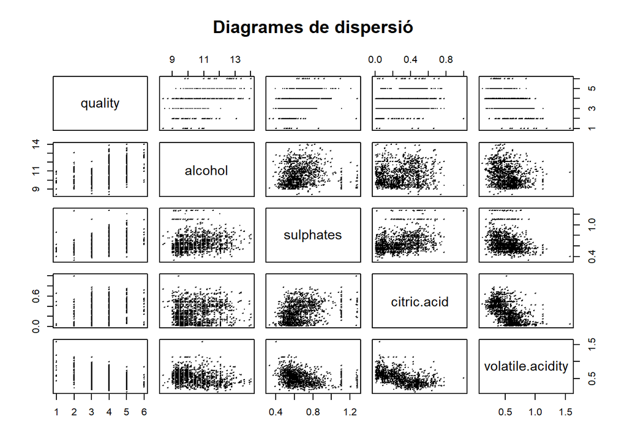

```r
# S'utilitza la funció "pairs".
pairs(quality ~ alcohol + sulphates + citric.acid + volatile.acidity, data=wine_red_x3, main="Diagrames de dispersió", pch=0.01, cex=.09)
```

Ara es procedeix a la modelització, on en primer lloc es divideix el *dataframe* **wine_red_x3** aleatòriament en un 66% per a entrenar i un 33% per realitzar proves on la variable a predir serà *quality*. Es generaran dos models de regressió lineal amb les dades disposades de forma aleatòria (desordenades):

- **model1** amb les quatre variables amb major grau de relació: *alcohol*, *sulphates*, *citric.acid* i *volatile.acidity*.
- **model2** només amb les dos variables amb major relació: *alcohol* i *sulphates*.

El millor models serà el que obtingui un coeficient de determinació $R^2$ més alt.

```r
set.seed(123)
# Es desordenen les files del dataframe wine_red_x3, que es el que té quality com a numèric:
wine_red_x3_random = wine_red_x31[sample(nrow(wine_red_x31)),]
# Obtenim x i y descomposant la variables pregunta (y) de la resta (x).
y = wine_red_x3_random[,length(wine_red_x31)]
X = wine_red_x3_random[, 1:length(wine_red_x31)-1]

# Extraiem un terç del total de files:
wine_red_x3terc= round(2/3*nrow(wine_red_x3_random))
# Definim els conjunts d'entrenament i test en base a wine_red_x3terc:
trainX <- X[1:wine_red_x3terc,]
trainy <- y[1:wine_red_x3terc]
testX  <- X[(wine_red_x3terc+1):nrow(wine_red_x3_random),]
testy  <- y[(wine_red_x3terc+1):nrow(wine_red_x3_random)]

#Definim 2 models amb regressors quantitaus segons les variables que més correlació tenen amb quality
model1 <- lm(trainy ~ alcohol + sulphates + citric.acid + volatile.acidity, data = trainX)
model2 <- lm(trainy ~ alcohol + sulphates, data = trainX)

model1
```

```
##
## Call:
## lm(formula = trainy ~ alcohol + sulphates + citric.acid + volatile.acidity,
##     data = trainX)
##
## Coefficients:
##      (Intercept)           alcohol         sulphates       citric.acid
##          0.52771           0.32699           0.61498          -0.01857
## volatile.acidity
##         -1.27804
```

```r
model2
```

```
##
## Call:
## lm(formula = trainy ~ alcohol + sulphates, data = trainX)
##
## Coefficients:
## (Intercept)      alcohol    sulphates
##     -0.8301       0.3676       1.0038
```

```r
# Avaluació de la qualitat dels models linials en base a R2:
summary(model1)$r.squared
```

```
## [1] 0.3475513
```

```r
summary(model2)$r.squared
```

```
## [1] 0.2804772
```

```r
taula <- matrix(c(1, summary(model1)$r.squared,
2, summary(model2)$r.squared),
ncol = 2, byrow = TRUE)
colnames(taula) <- c("Model", "R2")

taula
```

```
##      Model        R2
## [1,]     1 0.3475513
## [2,]     2 0.2804772
```

Amb els resultats obtinguts, el **model1** es el que presenta un coeficient de determinació major, $R^2=0.347$. Encara que certament, no es excessivament alt, ja que les quatre variables explicatives utilitzades (*alcohol*, *sulphates*, *citric.acid* i *volatile.acidity*) només expliquen poc més d’un terç (el 34.7%) de la variància de la variable dependent *quality*.

*Bibliografia*:

*Regressió lineal múltiple*. Document PDF a Recursos d’aprenentatge de l’assignatura Estadística Avançada.

https://github.com/mrc03/Red-Wine-Quality-Accuracy-0.9175-/blob/master/wine%20quality.ipynb

**Model de regressió logística**

```r
# Es crea una copia del dataset i la variable quality es passa a numèrica
wine_red_x32 <- wine_red_x3
wine_red_x32$quality <- as.numeric(as.character(wine_red_x32$quality))

# S'utilitza "ifelse" per la dicotomització
wine_red_x32$quality <- ifelse(wine_red_x32$quality >= 7, 1, 0)
```

Ara ja es pot realitzar la modelització, que al igual que per al cas de regressió lineal, es faran dos models: un amb les quatre variables amb més alt grau de relació amb *quality*, i un altre amb únicament les dues variables amb més correlació amb la variable dependent.

El resultat mostra de nou el model amb les 4 variables explicatives, com el que millor ajusta les dades. **model1_rl** obté un **criteri d’informació d’Akaike** (AIC) de 720.85, més baix que l’obtingut per **model2_rl**, que es de 770.49.

```r
#Definim 2 models amb regressors quantitaus segons les variables que més correlació tenen amb quality
model1_rl <- glm(quality ~ alcohol + sulphates + citric.acid + volatile.acidity, data = wine_red_x32)
model2_rl <- glm(quality ~ alcohol + sulphates, data = wine_red_x32)

# Avaluació de la qualitat dels models linials en base a R2:
summary(model1_rl)
```

```
##
## Call:
## glm(formula = quality ~ alcohol + sulphates + citric.acid + volatile.acidity,
##     data = wine_red_x32)
##
## Deviance Residuals:
##      Min        1Q    Median        3Q       Max
## -0.61666  -0.18043  -0.04414   0.04552   1.02824
##
## Coefficients:
##                   Estimate Std. Error t value Pr(>|t|)
## (Intercept)      -1.151717   0.093062 -12.376  < 2e-16 ***
## alcohol           0.117600   0.007298  16.113  < 2e-16 ***
## sulphates         0.239654   0.050259   4.768 2.03e-06 ***
## citric.acid       0.125221   0.050143   2.497   0.0126 *
## volatile.acidity -0.248440   0.051391  -4.834 1.46e-06 ***
## ---
## Signif. codes:  0 '***' 0.001 '**' 0.01 '*' 0.05 '.' 0.1 ' ' 1
##
## (Dispersion parameter for gaussian family taken to be 0.09149819)
##
##     Null deviance: 187.55  on 1598  degrees of freedom
## Residual deviance: 145.85  on 1594  degrees of freedom
## AIC: 720.85
##
## Number of Fisher Scoring iterations: 2
```

```r
summary(model2_rl)
```

```
##
## Call:
## glm(formula = quality ~ alcohol + sulphates, data = wine_red_x32)
##
## Deviance Residuals:
##      Min        1Q    Median        3Q       Max
## -0.62581  -0.18075  -0.05245   0.03620   1.01278
##
## Coefficients:
##              Estimate Std. Error t value Pr(>|t|)
## (Intercept) -1.420129   0.079586 -17.844  < 2e-16 ***
## alcohol      0.126638   0.007297  17.355  < 2e-16 ***
## sulphates    0.358394   0.048028   7.462 1.39e-13 ***
## ---
## Signif. codes:  0 '***' 0.001 '**' 0.01 '*' 0.05 '.' 0.1 ' ' 1
##
## (Dispersion parameter for gaussian family taken to be 0.09450077)
##
##     Null deviance: 187.55  on 1598  degrees of freedom
## Residual deviance: 150.82  on 1596  degrees of freedom
## AIC: 770.49
##
## Number of Fisher Scoring iterations: 2
```

Com es pot apreciar, també es comprova que s’acompleix que les variables seleccionades pels dos models (**model1_rl** i **model2_rl**) son significatives. Utilitzant el **test de Wald** pel contrast d’hipòtesi de nul·litat dels paràmetres, s’aprecia que a *Coefficients* (taula de resultats) el *p-value* associat, *Pr(>|t|)*, es menor al nivell de significança 0.05.

*Bibliografia*

*Models de regressió logística*. Document PDF a Recursos d’aprenentatge de l’assignatura Estadística Avançada.

**Model d’agregació (*clustering*)**

Seguint amb les respostes a les qüestions formulades a l’apartat 1, ara es pretén contestar si les diferents qualitats del vi que es troben en el *dataset* objecte d’estudi, responen a una correcta classificació. Amb aquest objectiu es construeix un model d’agregació per determinar si les agrupacions o *clusters* derivades dels valors dels diferents components del vi, determinen el seu grau de qualitat i si aquest es correcte amb la classificació que es fa a la variable *qualtiy* del *dataset*.

El *dataset* que es fa servir, es podria dir que ja fa una classificació supervisada, com així ho determina la variable *quality*. Però aquí es fa servir un mètode no supervisat, es a dir, es transforma el problema supervisat original en un de no supervistat. Amb la qual cosa, no es farà servir la variable *quality*, que es aquella que es pretén predeir. Aleshores es farà servir la resta de variables per predir la qualitat del vi.

Per realitzar aquesta modelització es fa servir l’algorisme *kmenas* i el primer pas serà agafar les dades, som s’ha dit, sense la variable *quality*:

```r
# S'agafa el dataset amb les dades netes
dades_agr <- wine_red_x3[,1:11]
```

Com no es coneix el nombre de *clusters* òptim, es prova amb diferents valors. Es fa tenint en compte que la variable *quality* tenia 6 classes que corresponia a aquests graus de qualitat: 3, 4, 5, 6, 7 i 8. Aleshores es prova amb valors de 2 a 8 i es mostra a una gràfica la silueta mitjana de cada prova per determinar quin nombre d’agregacions seria el millor.

El resultat mostra que el millor valor que s’obté es per a un k=2, però com que se sap que hi ha més graus per determinar la qualitat, s’utilitza el mètode *elbow* (colze), que no es més que l’anàlisi visual, on el k òptim es trobarà al colze de la gràfica. Es a dir, quan la corba comença a estabilitzar-se. En aquest cas, es podria afirmar que aquest punt estaria situat en un k al voltant del valor 5 i 6.

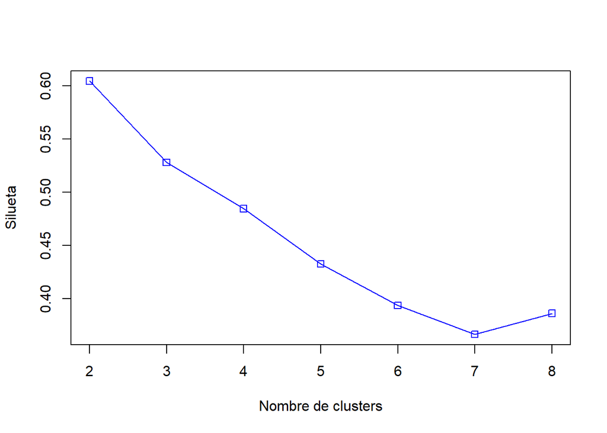

```r
set.seed(123)

# Es fa amb les funcions dasy i silhouette
d <- daisy(dades_agr)
resultats <- rep(0, 8)
for(i in c(2,3,4,5,6,7,8))
{
  fit <- kmeans(dades_agr, i)
  y_cluster <- fit$cluster
  sk <- silhouette(y_cluster, d)
  resultats[i] <- mean(sk[,3])
}

# S'obté la gràfica amb els valors de la silueta
plot(2:8,resultats[2:8],type="o",col="blue",pch=0,xlab="Nombre de clusters",ylab="Silueta")
```

Per determinar quin es el valor de k millor, s’aplica l’algorisme *kmeans* pels valors 5 i 6. I es visualitza mitjançant la funció *clusplot*, que com s’aprecia no aporta massa evidència.

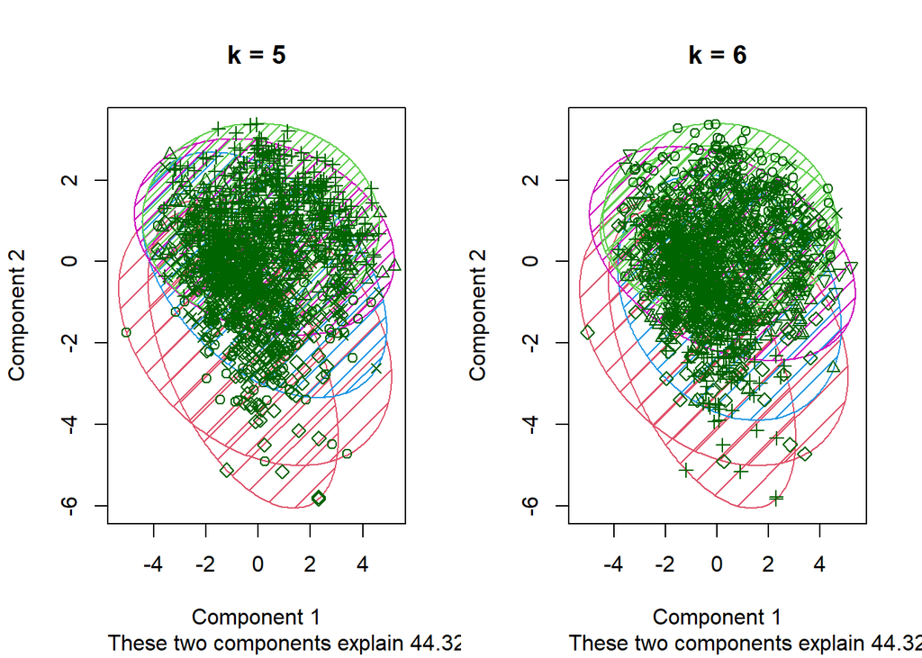

```r
# S'aplica kmeans per k=5
fit5 <- kmeans(dades_agr, 5)
# Identificador de k=5
k5 <- fit5$cluster

# S'aplica kmeans per k=6
fit6 <- kmeans(dades_agr, 6)
# Identificador de k=6
k6 <- fit6$cluster

par(mfrow=c(1,2))
clusplot(dades_agr, fit5$cluster,color=TRUE,shade=TRUE,lines=0,main="k = 5")
clusplot(dades_agr, fit6$cluster,color=TRUE,shade=TRUE,lines=0,main="k = 6")
```

Per tant s’haurà d’avaluar la qualitat de l’agregació. Es fa amb la funció *silhouette* que calcularà la silueta per un k=5 i k=6. La funció *silhouette* retorna per a cada mostra el *cluster* on s’ha assignat, el *cluster* veí i el valor de la silueta. Així que calculant la mitjana de la silueta (posició 3) s’obtindrà una estimació de la qualitat de l’agrupament.

El resultat mostra una mitjana major per una agrupació de **k=5**, per tant aquest nombre serà l’òptim. Confirmant-se que la classificació de la variable *quality*, amb 6 classes, no es la millor.

```r
# Es calcula la silueta de cada mostra
sk5 <- silhouette(k5,d)
sk6 <- silhouette(k6,d)

# mitjana de la silueta
mean(sk5[, 3])
```

```
## [1] 0.4324289
```

```r
mean(sk6[, 3])
```

```
## [1] 0.3935836
```

**Model de classificació**

Per respondre a la darrera pregunta de l’apartat 1, si existeixen paràmetres, patrons o regles que determinen la qualitat d’un vi, es realitza una model de classificació. En concret es modelitzarà un arbre de decisió. L’interès rau en descriure la relació entre la qualitat d’un vi (que es descriurà entre bo i dolent, com ja s’ha estat fent al llarg d’aquest treball) i cadascuna de les variables o components del vi.

Aleshores, l’objectiu es crear un arbre de decisió per analitzar què determina que un vi sigui bo. On la variable que es classificarà en bo o dolent, serà *quality*. Així que abans de res, transformarem la variable a classificar a *character*, seguint la regla que ja s’ha fet servir: el valor “Bo” per vins d’alta qualitat (valors majors o iguals a 7) i el valor “Dolent” pels de baixa qualitat (menors a 7).

```r
# Es crea una copia del dataset i la variable quality es passa a character
wine_red_x33 <- wine_red_x3
wine_red_x33$quality <- as.character(wine_red_x33$quality)

# S'utilitza "ifelse" per la dicotomització
wine_red_x33$quality <- ifelse(wine_red_x33$quality >= 7, "Bo", "Dolent")
```

El següent pas, i com s’ha de crear una mostra per entrenament (*trining*) i una altra per prova (*test*), serà desordenar les dades. De forma que aquestes, per cadascuna de les mostres, presenten una estructura molt semblant.

```r
set.seed(123)
# Es desordena i reanomena el dataset
wine_red_x33_random <- wine_red_x33[sample(nrow(wine_red_x33)),]
```

Després es determina la variable a classificar, que es *quality*, la darrera del *dataset*.

```r
set.seed(456)
# Es determina la variabla a classificar:
y_c <- wine_red_x33_random[,12]
x_c <- wine_red_x33_random[,1:11]
```

I s’efectue les particions, establint que la d’entrenament serà de 2/3 i la de prova d’1/3. Es fa amb la creació d’un rang.

```r
set.seed(789)
indexs = sample(1:nrow(wine_red_x33_random), size=floor((2/3)*nrow(wine_red_x33_random)))
train_x <- x_c[indexs,]
train_y <- y_c[indexs]
test_x  <- x_c[-indexs,]
test_y  <- y_c[-indexs]
```

Abans de la modelització, simplement queda fer una ullada a les mostres (*train* i *test*) per veure que no tenen excesives diferències.

```r
summary(train_x)
```

```
##  fixed.acidity    volatile.acidity  citric.acid     residual.sugar
##  Min.   : 4.600   Min.   :0.120    Min.   :0.0100   Min.   :1.200
##  1st Qu.: 7.100   1st Qu.:0.400    1st Qu.:0.1100   1st Qu.:1.900
##  Median : 7.900   Median :0.530    Median :0.2500   Median :2.200
##  Mean   : 8.306   Mean   :0.531    Mean   :0.2768   Mean   :2.542
##  3rd Qu.: 9.200   3rd Qu.:0.640    3rd Qu.:0.4200   3rd Qu.:2.600
##  Max.   :15.200   Max.   :1.580    Max.   :1.0000   Max.   :6.060
##    chlorides       free.sulfur.dioxide total.sulfur.dioxide    density
##  Min.   :0.03800   Min.   : 1.00       Min.   :  6.00       Min.   :0.9908
##  1st Qu.:0.07000   1st Qu.: 8.00       1st Qu.: 22.00       1st Qu.:0.9956
##  Median :0.08000   Median :14.00       Median : 38.00       Median :0.9968
##  Mean   :0.08753   Mean   :16.11       Mean   : 46.69       Mean   :0.9968
##  3rd Qu.:0.09100   3rd Qu.:22.00       3rd Qu.: 63.00       3rd Qu.:0.9980
##  Max.   :0.27000   Max.   :53.00       Max.   :153.00       Max.   :1.0015
##        pH          sulphates         alcohol
##  Min.   :2.880   Min.   :0.3700   Min.   : 8.40
##  1st Qu.:3.210   1st Qu.:0.5500   1st Qu.: 9.50
##  Median :3.310   Median :0.6200   Median :10.10
##  Mean   :3.312   Mean   :0.6535   Mean   :10.41
##  3rd Qu.:3.400   3rd Qu.:0.7300   3rd Qu.:11.10
##  Max.   :3.750   Max.   :1.2800   Max.   :14.00
```

```r
summary(test_x)
```

```
##  fixed.acidity    volatile.acidity  citric.acid     residual.sugar
##  Min.   : 5.000   Min.   :0.1200   Min.   :0.0100   Min.   :1.200
##  1st Qu.: 7.100   1st Qu.:0.3900   1st Qu.:0.1100   1st Qu.:1.900
##  Median : 7.900   Median :0.5000   Median :0.2700   Median :2.200
##  Mean   : 8.347   Mean   :0.5216   Mean   :0.2872   Mean   :2.533
##  3rd Qu.: 9.400   3rd Qu.:0.6400   3rd Qu.:0.4400   3rd Qu.:2.600
##  Max.   :15.200   Max.   :1.1300   Max.   :0.7800   Max.   :6.060
##    chlorides       free.sulfur.dioxide total.sulfur.dioxide    density
##  Min.   :0.03800   Min.   : 1.0        Min.   :  6.00       Min.   :0.9918
##  1st Qu.:0.07100   1st Qu.: 7.0        1st Qu.: 22.00       1st Qu.:0.9958
##  Median :0.07900   Median :13.0        Median : 37.00       Median :0.9968
##  Mean   :0.08701   Mean   :15.4        Mean   : 46.03       Mean   :0.9968
##  3rd Qu.:0.09000   3rd Qu.:21.0        3rd Qu.: 60.00       3rd Qu.:0.9979
##  Max.   :0.26000   Max.   :53.0        Max.   :155.00       Max.   :1.0010
##        pH         sulphates         alcohol
##  Min.   :2.92   Min.   :0.3300   Min.   : 8.40
##  1st Qu.:3.22   1st Qu.:0.5500   1st Qu.: 9.60
##  Median :3.31   Median :0.6300   Median :10.20
##  Mean   :3.31   Mean   :0.6677   Mean   :10.45
##  3rd Qu.:3.40   3rd Qu.:0.7400   3rd Qu.:11.07
##  Max.   :3.68   Max.   :1.2800   Max.   :13.92
```

Ara ja es pot realitzar la modelització de l’arbre de decisió utilitzant l’algorisme *C5.0* de *Quinlan*. On en primer lloc s’obté el resultat amb les dades de *train*.

```r
set.seed(123)
# S'utilitza l'algorisme C50
model_C50 <-  C5.0(train_x, as.factor(train_y),rules=TRUE)

# S'observen els resultats:
summary(model_C50)
```

```
##
## Call:
## C5.0.default(x = train_x, y = as.factor(train_y), rules = TRUE)
##
##
## C5.0 [Release 2.07 GPL Edition]      Thu May 20 23:50:05 2021
## -------------------------------
##
## Class specified by attribute `outcome'
##
## Read 1066 cases (12 attributes) from undefined.data
##
## Rules:
##
## Rule 1: (17, lift 7.2)
##  volatile.acidity > 0.27
##  volatile.acidity <= 0.37
##  total.sulfur.dioxide <= 45
##  sulphates > 0.8
##  alcohol > 10.75
##  ->  class Bo  [0.947]
##
## Rule 2: (5, lift 6.5)
##  fixed.acidity > 11.5
##  density <= 0.99785
##  sulphates > 0.65
##  alcohol <= 10.75
##  ->  class Bo  [0.857]
##
## Rule 3: (11/1, lift 6.4)
##  fixed.acidity > 10.4
##  volatile.acidity <= 0.37
##  alcohol > 10.75
##  alcohol <= 11.6
##  ->  class Bo  [0.846]
##
## Rule 4: (4, lift 6.3)
##  fixed.acidity > 11.5
##  volatile.acidity <= 0.32
##  sulphates > 0.81
```

[output cut: 87 more lines]

```
##
##  Attribute usage:
##
##   96.81% alcohol
##   85.83% sulphates
##   85.74% volatile.acidity
##   76.55% fixed.acidity
##   75.61% density
##   56.00% residual.sugar
##   34.62% total.sulfur.dioxide
##    7.79% chlorides
##    1.22% pH
##
##
## Time: 0.0 secs
```

S’han obtingut 15 regles (8 per classificar “Bo” i 7 per “Dolent”) on el percentatge de classificacions errònies entre vins bons i dolents, es del **7.0%** (75 casos mal classificats d’un total de 1066). Les regles semblen clares, però es comenten la millor que classifica el vi “bo” i la millor que classifica el vi “dolent”:

- *Regla 1*: si un vi conté *volatile.acidity* major a 0.27$g/dm^3$ i menor o igual a 0.37$g/dm^3$ , *total.sulfur.dioxide* menor o igual a 45$g/dm^3$, *sulphates* major a 0.8$g/dm^3$ i *alcohol* major a 10.75%; serà “Bo” amb una probabilitat del 94.7%.
- *Regla 9*: si un vi conté *residual.sugar* menor o igual a 3.3$g/dm^3$, *density* major de 0.99785$g/cm^3$, *sulphates* menor o igual a 0.81$g/dm^3$ i *alcohol* menor o igual a 10.75%; serà “Dolent” en una probabilitat del 98.0%.

I per finalitzar, es valida el model amb les dades de *test* (reservades), per veure l’eficiència de la seva predicció. Que com s’aprecia, es d’un 85.55%.

```r
# S'utilitza la funció "predict"
prediccio_model_C50 <- predict(model_C50, test_x, type="class")
print(sum(prediccio_model_C50 == test_y) / length(prediccio_model_C50))
```

```
## [1] 0.8555347
```

# 5. Representació dels resultats a partir de taules i gràfiques.

A continuació es resumeixen els resultats obtinguts amb les diferents modelitzacions realitzades.

**Resultat del model de regressió lineal**

Es realitza la predicció i avaluació de la precisió del model amb la funció *predict()*:

```r
# Predicció de qualitat amb el model 2
dades <- data.frame(alcohol=testX$alcohol, sulphates=testX$sulphates, volatile.acidity=testX$volatile.acidity, citric.acid=testX$citric.acid)
prediccio=unname(predict(model2, dades))
prediccio
```

```
##   [1] 4.855310 3.902698 4.527449 3.621919 3.364467 3.421444 3.120446 3.772061
##   [9] 3.330959 3.889266 2.959981 3.133735 3.692042 3.080437 3.254049 3.852508
##  [17] 4.036300 3.949922 3.458060 3.925882 3.284448 3.204144 3.638458 3.340997
##  [25] 3.314277 3.224077 2.928170 3.294343 3.284163 3.592375 4.758038 4.339416
##  [33] 3.635208 4.379568 3.117195 3.742232 3.484923 4.005901 4.591213 3.978048
##  [41] 3.531434 3.595056 4.042944 4.477402 3.260836 3.885730 5.052534 3.327566
##  [49] 4.611147 3.280912 3.959389 3.919095 3.879228 3.762308 4.467221 3.504856
##  [57] 3.067005 3.762165 3.996005 4.002935 3.504856 3.364467 3.367718 4.457326
##  [65] 3.060361 3.304239 4.741784 3.424695 3.775597 3.330959 3.475027 4.149826
##  [73] 4.042802 3.401368 3.742232 3.899304 3.284305 3.254049 3.675360 3.434733
##  [81] 4.169902 3.417908 3.194106 3.307632 4.233239 3.330959 3.157205 4.026405
##  [89] 4.043087 3.107015 3.267623 3.488174 2.846169 3.448022 4.086347 3.332799
##  [97] 5.079676 3.641852 3.204001 3.334353 3.969427 4.367269 4.537630 4.243419
## [105] 3.190712 4.283571 3.113802 4.236775 3.254049 3.598449 5.058893 3.157347
## [113] 3.779133 3.408012 3.417765 3.668858 4.046195 3.284305 3.334495 4.146433
```

[output cut: 52 more lines]

```r
# Recompte quantes equivalència entre les prediccion si els valors origninals per a qualitat de vi hi ha.
# Obtenim la diferència entre els valors de qualitat i tenim en compte quant són encerts (valor 0) per estimar la precisió:
rr=round(prediccio-testy)
table(rr==0)
```

```
##
## FALSE  TRUE
##   218   315
```

```r
Perc = 100*table(rr==0)/length(testy)
Perc
```

```
##
##    FALSE     TRUE
## 40.90056 59.09944
```

Per observar la normalitat de la distribució dels errors, s’utilitza el gràfic *Q-Q*, per comparar-la amb una hipotètica distribució normal perfecta. On tot i alguna divergència, es pot assumir la normalitat dels errors.

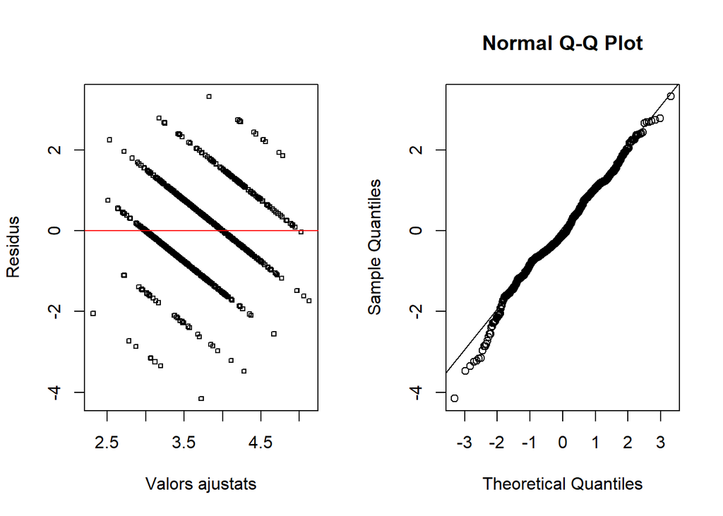

```r
# s'obtenen els residus amb "rstandard"
residus<-rstandard(model1)

par(mfrow=c(1,2))
# Diagrama de valors ajustats i residus
plot(fitted.values(model1),rstandard(model1),xlab="Valors ajustats",ylab="Residus",pch=0.5, cex=0.5)
abline(h=0, col="red")

# Es dibuixa el gràfic "QQplot" pels residus
qqnorm(residus)
qqline(residus)
```

*Bibliografia*:

*Regressió lineal múltiple*. Document PDF a Recursos d’aprenentatge de l’assignatura Estadística Avançada.

**Resultat del model de regressió logística**

Per mesurar la bondat de l’ajust d’aquest model de regressió logística, s’utilitza **el test** *Hosman-Lemeshow*. On el test compara els valors previstos pel model amb els valors observats. La hipòtesi nul·la ($H_0$) indicarà que no hi ha diferència entre els valors observats i pronosticats i el seu rebuig ($H_1$) que el model no està ben ajustat.

El resultat del test dona un *p-value*, 0.4196, major que el nivell de significança, 0.05. Amb la qual cosa no es pot rebutjar la hipòtesi nul·la, es a dir, s’ha de concloure en què el model ajusta bé les dades.

```r
# Es realitza el test
hoslem.test(wine_red_x32$quality,fitted(model1_rl))
```

```
##
##  Hosmer and Lemeshow goodness of fit (GOF) test
##
## data:  wine_red_x32$quality, fitted(model1_rl)
## X-squared = 8.1433, df = 8, p-value = 0.4196
```

Per testejar la capacitat predictiva del model de regressió logística, es pot utilitzar les corbes ROC. Que proporcionen una forma de seleccionar les modelitzacions més òptimes, basada en la qualitat de la classifiació. Per a la qual cosa es calcula l’àrea sota la corba o *AUROC*.

Aquí es compararen les corbes *ROC* i les àrees *AUROC* dels models realitzats: **model1_rl** i **model2_rl**, d’aquesta forma es pot comparar els resultats obtinguts.

```r
par(mfrow=c(1,2))

# Primer es fa la corba pel model1_rl, on es necessita crear el predictor.
# Després s'utilitza la funció ROC, on el primer argument es la variable
# dependent dicotòmica, el segon el predictor i el tercer el dataset
# wine_red_x32. Per finalitzar es fa el gràfic i es calcula l'àrea.
model1_rl_p = predict(model1_rl,wine_red_x32,type="response")
model1_rl_p = roc(wine_red_x32$quality,model1_rl_p,data=wine_red_x32)
plot(model1_rl_p)
auc(model1_rl_p)
```

```
## Area under the curve: 0.867
```

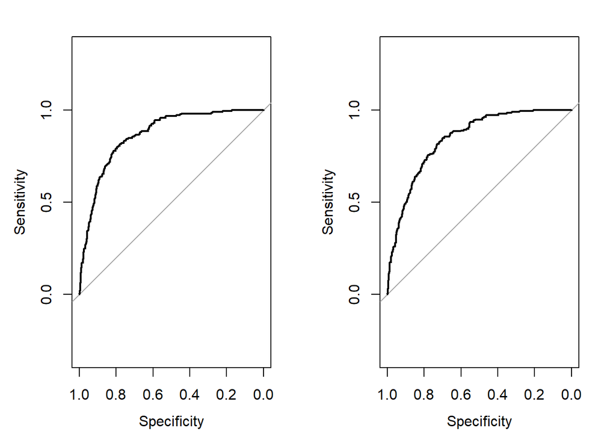

```r
# Es fa el mateix pel model model2_rl
model2_rl_p = predict(model2_rl,wine_red_x32,type="response")
model2_rl_p = roc(wine_red_x32$quality,model2_rl_p,data=wine_red_x32)
plot(model2_rl_p)
```

```r
auc(model2_rl_p)
```

```
## Area under the curve: 0.8449
```

Els resultats obtinguts son força semblants, amb **model1_rl** l’àrea *AUROC* es de 0.867 i amb el **model2_rl** de 0.8449. Però, confirmant-se el que ja s’havia vist amb l’*AIC*, el primer es una mica millor. Però per ambdós casos, les modelitzacions discriminen de forma excel·lent (ja que $0.8 \le AUROC < 0.9$).

*Bibliografia*

- *Models de regressió logística*. Recursos d’aprenentatge. Document PDF a Recursos d’aprenentatge de l’assignatura Estadística Avançada.

**Resultat del model d’agregació (*clustering*)**

Com ja s’ha explicat, amb la modelització *kmeans* s’evidencia que l’agregació òptima de la qualitat del vi es de 5 *clusters*, a diferència de les classes de la variable *quality* que en te 6 (3, 4, 5, 6, 7 i 8). Per tant, aquesta darrera classificació no resultava correcta i es més adient l’obtinguda amb el model d’agregació.

Però paga la pena observar com es comporta aquest resultat amb *kmeans* respecte a la classificació de la variable *quality*. Ja que a banda de comprovar-se la no idoneïtat de la classificació per *quality* del *dataset*, s’identifiquen les variables que diferencien millor els grups o *clusters*.

Amb aquest objectiu, en primer lloc s’obté el *clustering* agafant les variables 2 a 2. Que com es pot observar, tot i que amb certa dificultat, destaca *total.sulfur.dioxide* perquè diferencia molt nítidament els 5 *clusters* i per gairebé totes les variables.

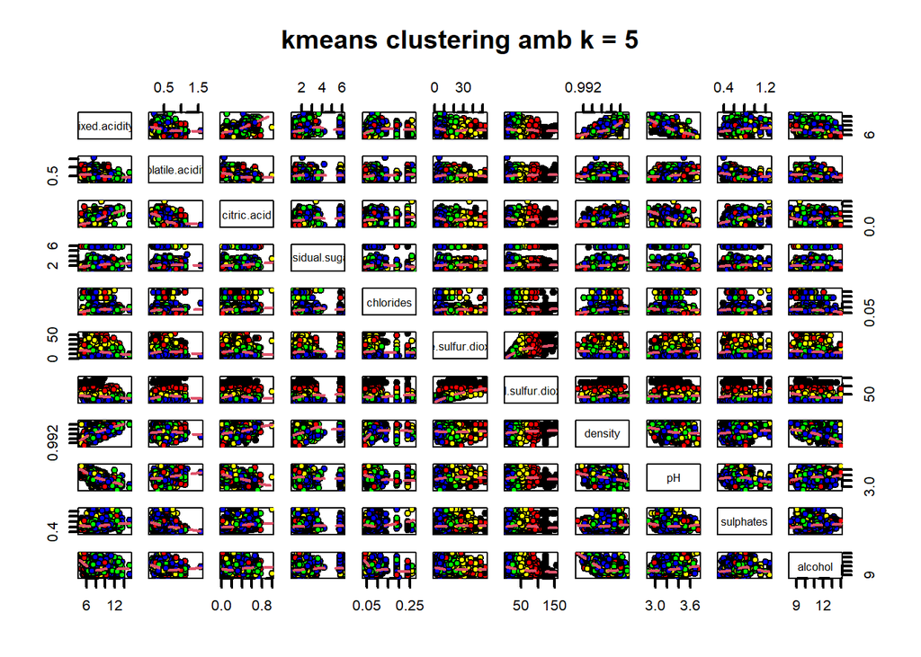

```r
# Agrupació amb kmeans
vins_k_5 <- kmeans(dades_agr, 5)

# Visualitzar el clustering agafant les variables 2 a 2
pairs(dades_agr, main="kmeans clustering amb k = 5", panel=panel.smooth, pch=21, bg=c("red","green","blue", "yellow", "black")[unclass(fit5$cluster)],lwd=2,lty=2)
```

S’aprecia amb major claredat agafant únicament aquesta variable junt amb *density* (que es la que la precedeix), com es pot veure baix a la gràfica *kmean clustering* on els *clusters* estan perfectament definits amb els diferents colors. A banda de què es comprova que el resultat de la modelització no es correspon en absolut amb la classificació original del *dataset* (variable *quality*), a la gràfica *Dataset* les agrupacions originals de les dades estan molt desordenades. Establint-se també, *total.sulfur.dioxide*, com la variable que millor classifica les dades.

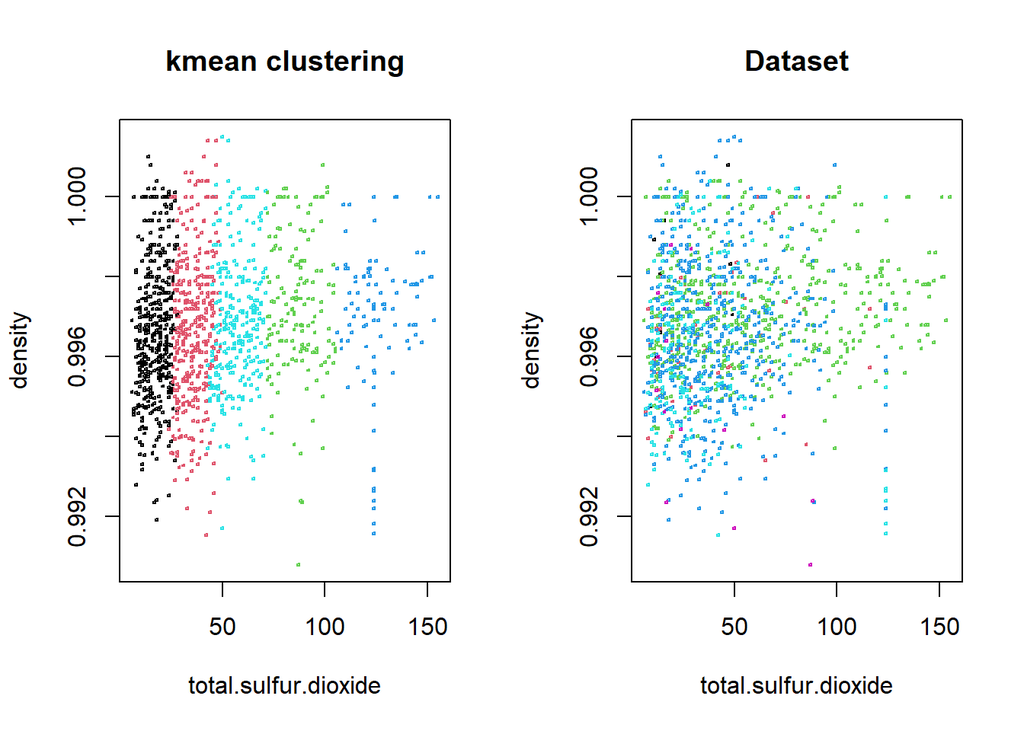

```r
par(mfrow=c(1,2))

# Gràfica amb l'agrupació kmeans
plot(dades_agr[c(7,8)], col=vins_k_5$cluster, pch=0.2, cex=0.2, main= "kmean clustering")

# Agrupació de la variable quality
plot(dades_agr[c(7,8)], col=wine_red_x3$quality, pch=0.2, cex=0.2, main="Dataset")
```

Per finalitzar, es pot obtenir el *cluster* al que pertany cadascuna de les observacions.

```r
vins_k_5$cluster
```

```
##    1    2    3    4    5    6    7    8    9   10   11   12   13   14   15   16
##    2    1    1    5    1    1    2    5    1    1    2    1    2    5    2    4
##   17   18   19   20   21   22   23   24   25   26   27   28   29   30   31   32
##    3    5    1    2    1    2    5    5    5    5    2    1    1    3    1    1
##   33   34   35   36   37   38   39   40   41   42   43   44   45   46   47   48
##    3    1    1    1    1    5    5    1    3    1    1    5    1    2    4    1
##   49   50   51   52   53   54   55   56   57   58   59   60   61   62   63   64
##    1    2    2    1    1    2    5    1    2    1    2    1    1    1    1    2
##   65   66   67   68   69   70   71   72   73   74   75   76   77   78   79   80
##    5    5    2    2    5    3    5    3    5    2    4    4    5    5    2    5
##   81   82   83   84   85   86   87   88   89   90   91   92   93   94   95   96
##    1    1    2    2    3    4    5    3    3    1    1    4    2    1    3    1
##   97   98   99  100  101  102  103  104  105  106  107  108  109  110  111  112
##    4    5    1    4    5    5    4    5    1    1    2    1    5    3    3    3
##  113  114  115  116  117  118  119  120  121  122  123  124  125  126  127  128
```

[output cut: 185 more lines]

**Resultat del model de classificació (*arbre de decisió*)**

Amb aquesta modelització d’arbre de decisió, en la que s’ha utilitzat l’agorisme *C5.0*, s’han obtingut 15 regles que determinen un vi “Bo” i un de “Dolent”. En primer lloc es visualitza l’arbre del model:

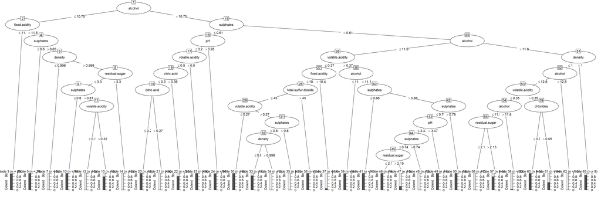

```r
set.seed(123)
# Es visualitza l'arbre de decisió resultant
model_C50 <- C5.0(train_x, as.factor(train_y), type = "simple")
plot(model_C50)
```

Per resumir les dades de la modelització s’obté aquesta matriu de confusió:

```r
confusionMatrix(table(test_y,Predicted=prediccio_model_C50))
```

```
## Confusion Matrix and Statistics
##
##         Predicted
## test_y    Bo Dolent
##   Bo      28     49
##   Dolent  28    428
##
##                Accuracy : 0.8555
##                  95% CI : (0.8228, 0.8843)
##     No Information Rate : 0.8949
##     P-Value [Acc > NIR] : 0.99817
##
##                   Kappa : 0.3409
##
##  Mcnemar's Test P-Value : 0.02265
##
##             Sensitivity : 0.50000
##             Specificity : 0.89727
##          Pos Pred Value : 0.36364
##          Neg Pred Value : 0.93860
##              Prevalence : 0.10507
##          Detection Rate : 0.05253
##    Detection Prevalence : 0.14447
##       Balanced Accuracy : 0.69864
##
##        'Positive' Class : Bo
##
```

I per veure més en detall tota la informació referent al nombre de classificacions correctes i incorrectes, s’obté aquesta altra matriu de confusió:

```r
CrossTable(test_y, prediccio_model_C50,prop.chisq  = FALSE, prop.c = FALSE, prop.r =FALSE,dnn = c('Reality', 'Prediction'))
```

```
##
##
##    Cell Contents
## |-------------------------|
## |                       N |
## |         N / Table Total |
## |-------------------------|
##
##
## Total Observations in Table:  533
##
##
##              | Prediction
##      Reality |        Bo |    Dolent | Row Total |
## -------------|-----------|-----------|-----------|
##           Bo |        28 |        49 |        77 |
##              |     0.053 |     0.092 |           |
## -------------|-----------|-----------|-----------|
##       Dolent |        28 |       428 |       456 |
##              |     0.053 |     0.803 |           |
## -------------|-----------|-----------|-----------|
## Column Total |        56 |       477 |       533 |
## -------------|-----------|-----------|-----------|
##
##
```

# 6. Resolució del problema. A partir dels resultats obtinguts, quines són les conclusions? Els resultats permeten respondre al problema?

Després de la realització de les diferents modelitzacions per contestar les preguntes o problemes plantejats, aquestes son les conclusions:

Seguint amb les conclusions, per la resposta a la pregunta de quantes classes de vi existeixen en funció de la qualitat, s’ha realitzat un *model d’agregació* amb l’algorisme *kmenas*. On la qualitat d’aquesta modelització, mesurada amb la mitjana de la silueta (*silhouette*), es la que correspon a una agrupació de *k*=**5** (millor que per *k*=6), amb un resultat de 0.432. No sembla una xifra per la mitjana excesivament elevada, però sí ho es per determinar que la millor agrupació es amb 5 *clusters*. El model també estableix la variable *total.sulfur.dioxide*, com la que millor classifica (com s’ha vist a l’apartat anterior) les dades pels diferents *clusters*.

# 7. Codi: Cal adjuntar el codi, preferiblement en R, amb el que s’ha realitzat la neteja, anàlisi i representació de les dades. Si ho preferiu, també podeu treballar en Python.